# Python for Data Science

#### DAY 1

#### Why Python Libraries?

Comparing Python data structures with Numpy data structures

```python
%%time
# above code is used to calculate execution time of a cell in Jupyter, it has to be present as the first line of code.
list1 = list(range(1,1000000))
list2 = list(range(2,1000001))

list3 = []
for i in range(len(list1)):
    list3.append(list1[i]+list2[i])

# Checking for memory allocation
# sys module provides functions and variables used to manipulate different parts of the Python runtime environment.
import sys
print("No. of bytes in memory used: ",sys.getsizeof(list3))
```

```
No. of bytes in memory used:  8448728
CPU times: user 228 ms, sys: 19.1 ms, total: 247 ms
Wall time: 250 ms
```

```python
#Importing Numpy
import numpy as np
```

```python
%%time
# above code is used to calculate execution time of a cell in Jupyter, it has to be present as the first line of code.

#Creating a numpy array of 1 million numbers
a = np.arange(1,1000000)
b = np.arange(2,1000001)
c = a+b

# checking memory allocation
print("No. of bytes in memory used: ",c.nbytes)
```

```
No. of bytes in memory used:  7999992
CPU times: user 4.81 ms, sys: 4.94 ms, total: 9.76 ms
Wall time: 151 ms
```

### Business Scenario

RestoreMasters is a car restoration company based in New York, USA.

Within short span of time, this company has become renowned for restoring vintage cars.

Their team takes great pride in each of their projects, no matter how big or small. They offer paint jobs, frame build-ups, engine restoration, body work etc. They restore cars of various origins including USA, Europe and Asia

The management wants to expand their business by increasing the capacity of the number of cars that can be restored.

They want to generate greater revenue for the company through cost cutting and providing a data driven approach to their current process.

They feel that the insights from existing data will help them in making data-driven decisions and also automate some of the key tasks in the process.

Key Objectives:

1. Getting Insights to make data-driven business decisions.  
   Example: Decision to decentralize restoration work with specialized facility.
2. Usage of Machine learning models that can help in automating important tasks.  
   Example:
   - Predicting the mileage of incoming cars
   - Automated classification of incoming cars

### Data Analysis Process

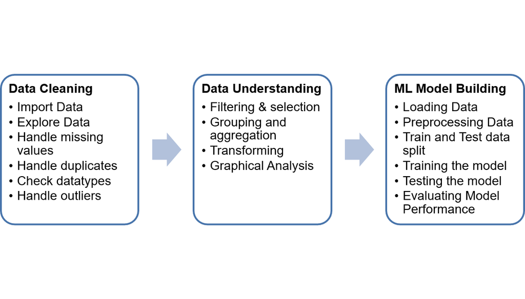

### Python Version Check

```python
from platform import python_version

print(python_version())
```

```
3.9.7
```

In Python, Code organization is done through modules and packages.

A Module is a python file with a .py extension.

A package is a folder which contains modules.

Package can store many python modules/files in it.

Before we make use of the packages, we need to import them using “import” command into the workspace. To ease the usage, packages are imported with alias names.

Standard alias names are ‘np’ for numpy, ‘pd’ for pandas and ‘plt’ for matplotlib.pyplot

```python
# importing packages
import numpy as np
import pandas as pd
import matplotlib.pyplot as plt
```

### Data Cleaning

- Step 1: Importing the dataset
- Step 2: Exploring Data
- Step 3: Handling Missing Values
- Step 4: Handling Duplicates
- Step 5: Checking column data types
- Step 6: Handling outliers

#### Step 1: Importing the dataset

```python
# importing the dataset to Pandas DataFrame: cars_df
cars_df=pd.read_csv('cars93.csv')
```

A Pandas DataFrame is a two-dimensional data structure that stores data in a tabular format of rows and columns.

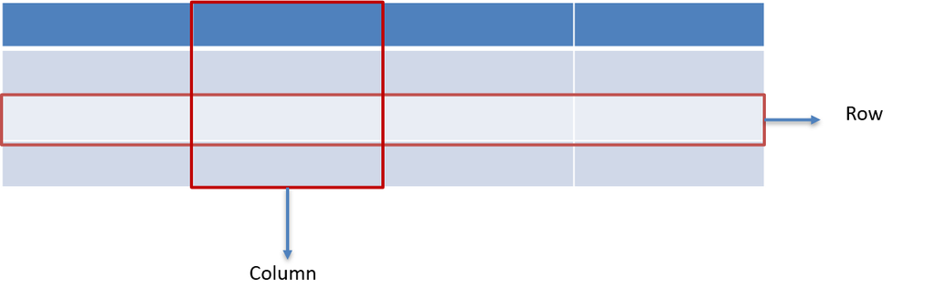

Every column in a DataFrame is a Pandas Series object.

Pandas DataFrame object contains attributes and methods. Attributes represents the characteristics. Example: shape, dtype Methods represents the actions that can be carried on DataFrame. Example: info(), describe()

Pandas can read a variety of files.

For example:

a table of fixed width formatted lines (read_fwf), excel sheets (read_excel), html files (read_html), json files (read_json)

```python
# display the data in DataFrame: cars_df
cars_df
```

|  | mpg | cylinders | displacement | horsepower | weight | acceleration | model_year | origin | name |
| --- | --- | --- | --- | --- | --- | --- | --- | --- | --- |
| 0 | 18.0 | 8 | 307.0 | 130.0 | 3504 | 12.0 | 70 | usa | chevrolet chevelle malibu |
| 1 | 15.0 | 8 | 350.0 | 165.0 | 3693 | 11.5 | 70 | usa | buick skylark 320 |
| 2 | 18.0 | 8 | 318.0 | 150.0 | 3436 | 11.0 | 70 | usa | plymouth satellite |
| 3 | 16.0 | 8 | 304.0 | 150.0 | 3433 | 12.0 | 70 | usa | amc rebel sst |
| 4 | 17.0 | 8 | 302.0 | 140.0 | 3449 | 10.5 | 70 | usa | ford torino |
| ... | ... | ... | ... | ... | ... | ... | ... | ... | ... |
| 393 | 27.0 | 4 | 140.0 | 86.0 | 2790 | 15.6 | 82 | usa | ford mustang gl |
| 394 | 44.0 | 4 | 97.0 | 52.0 | 2130 | 24.6 | 82 | europe | vw pickup |
| 395 | 32.0 | 4 | 135.0 | 84.0 | 2295 | 11.6 | 82 | usa | dodge rampage |
| 396 | 28.0 | 4 | 120.0 | 79.0 | 2625 | 18.6 | 82 | usa | ford ranger |
| 397 | 31.0 | 4 | 119.0 | 82.0 | 2720 | 19.4 | 82 | usa | chevy s-10 |

398 rows × 9 columns

```python
#display first five rows of the DataFrame: cars_df
cars_df.head()
```

|  | mpg | cylinders | displacement | horsepower | weight | acceleration | model_year | origin | name |
| --- | --- | --- | --- | --- | --- | --- | --- | --- | --- |
| 0 | 18.0 | 8 | 307.0 | 130.0 | 3504 | 12.0 | 70 | usa | chevrolet chevelle malibu |
| 1 | 15.0 | 8 | 350.0 | 165.0 | 3693 | 11.5 | 70 | usa | buick skylark 320 |
| 2 | 18.0 | 8 | 318.0 | 150.0 | 3436 | 11.0 | 70 | usa | plymouth satellite |
| 3 | 16.0 | 8 | 304.0 | 150.0 | 3433 | 12.0 | 70 | usa | amc rebel sst |
| 4 | 17.0 | 8 | 302.0 | 140.0 | 3449 | 10.5 | 70 | usa | ford torino |

```python
#display last five rows of the DataFrame: cars_df
cars_df.tail()
```

|  | mpg | cylinders | displacement | horsepower | weight | acceleration | model_year | origin | name |
| --- | --- | --- | --- | --- | --- | --- | --- | --- | --- |
| 393 | 27.0 | 4 | 140.0 | 86.0 | 2790 | 15.6 | 82 | usa | ford mustang gl |
| 394 | 44.0 | 4 | 97.0 | 52.0 | 2130 | 24.6 | 82 | europe | vw pickup |
| 395 | 32.0 | 4 | 135.0 | 84.0 | 2295 | 11.6 | 82 | usa | dodge rampage |
| 396 | 28.0 | 4 | 120.0 | 79.0 | 2625 | 18.6 | 82 | usa | ford ranger |
| 397 | 31.0 | 4 | 119.0 | 82.0 | 2720 | 19.4 | 82 | usa | chevy s-10 |

#### Step 2: Exploring Data

```python
# Check the number of rows and  number of columns in Pandas DataFrame: cars_df
cars_df.shape
```

```
(398, 9)
```

```python
# check the row index labels of Pandas DataFrame: cars_df
cars_df.index
```

```
RangeIndex(start=0, stop=398, step=1)
```

```python
# Check the column labels of Pandas DataFrame: cars_df
cars_df.columns
```

```
Index(['mpg', 'cylinders', 'displacement', 'horsepower', 'weight',
       'acceleration', 'model_year', 'origin', 'name'],
      dtype='object')
```

```python
# Get the concise summary of DataFrame: cars_df
cars_df.info()
```

```
<class 'pandas.core.frame.DataFrame'>
RangeIndex: 398 entries, 0 to 397
Data columns (total 9 columns):
 #   Column        Non-Null Count  Dtype
---  ------        --------------  -----
 0   mpg           398 non-null    float64
 1   cylinders     398 non-null    int64
 2   displacement  398 non-null    float64
 3   horsepower    392 non-null    float64
 4   weight        398 non-null    int64
 5   acceleration  398 non-null    float64
 6   model_year    398 non-null    int64
 7   origin        398 non-null    object
 8   name          398 non-null    object
dtypes: float64(4), int64(3), object(2)
memory usage: 28.1+ KB
```

```python
# Get the statistical summary of numeric columns of DataFrame: cars_df
cars_df.describe()
```

|  | mpg | cylinders | displacement | horsepower | weight | acceleration | model_year |
| --- | --- | --- | --- | --- | --- | --- | --- |
| count | 398.000000 | 398.000000 | 398.000000 | 392.000000 | 398.000000 | 398.000000 | 398.000000 |
| mean | 23.514573 | 5.454774 | 193.425879 | 104.469388 | 2970.424623 | 15.568090 | 76.010050 |
| std | 7.815984 | 1.701004 | 104.269838 | 38.491160 | 846.841774 | 2.757689 | 3.697627 |
| min | 9.000000 | 3.000000 | 68.000000 | 46.000000 | 1613.000000 | 8.000000 | 70.000000 |
| 25% | 17.500000 | 4.000000 | 104.250000 | 75.000000 | 2223.750000 | 13.825000 | 73.000000 |
| 50% | 23.000000 | 4.000000 | 148.500000 | 93.500000 | 2803.500000 | 15.500000 | 76.000000 |
| 75% | 29.000000 | 8.000000 | 262.000000 | 126.000000 | 3608.000000 | 17.175000 | 79.000000 |
| max | 46.600000 | 8.000000 | 455.000000 | 230.000000 | 5140.000000 | 24.800000 | 82.000000 |

describe() method of DataFrame provides the basic statistics of all numerical columns of the DataFrame. The describe() method returns the predefined statistics for numeric columns which includes: count, mean, std, min, 25%, 50%, 75%, max

DataFrame Axes:

DataFrame consists of 2 axes:

axis = 0 --- represents rows

axis = 1 --- represents columns

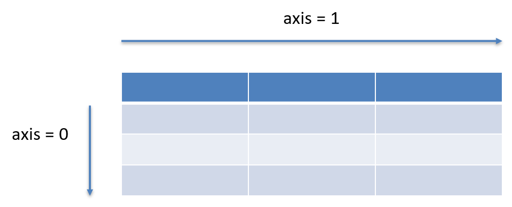

#### Step 3: Handling Missing Values

Datasets can contain missing values. This can be handled in 2 ways:

1. Remove missing values. Rows or columns containing missing values can be removed.

   **pandas.DataFrame.dropna()** method can be used to drop missing values in the DataFrame. It takes the axis parameter which can have two values 0 or 1

   If axis=0 , it will drop rows containing missing values If axis=1, it will drop columns containing missing values
1. Replacing the missing values with new values . This is also called as imputation.

```python
# finding missing values using isna() and any() in columns of the DataFrame: cars_df
cars_df.isna().any()
```

```
mpg             False
cylinders       False
displacement    False
horsepower       True
weight          False
acceleration    False
model_year      False
origin          False
name            False
dtype: bool
```

**pandas.DataFrame.isna()** method helps in detecting missing values in the DataFrame. Method returns the entire DataFrame object with boolean values.

Values in the DataFrame such as NaN and None will be mapped as ‘True’ and all other values are mapped as ‘False’

**pandas.DataFrame.any(axis=0)** method checks if any element consists of Boolean – ‘True’ over columns

Method reduces the index and returns the Series object with column names as index.

```python
# finding the number of missing values in each of the columns of the DataFrame: cars_df
cars_df.isna().sum()
```

```
mpg             0
cylinders       0
displacement    0
horsepower      6
weight          0
acceleration    0
model_year      0
origin          0
name            0
dtype: int64
```

```python
# finding the rows where missing values are present
cars_df[cars_df['horsepower'].isnull()]
```

|  | mpg | cylinders | displacement | horsepower | weight | acceleration | model_year | origin | name |
| --- | --- | --- | --- | --- | --- | --- | --- | --- | --- |
| 32 | 25.0 | 4 | 98.0 | NaN | 2046 | 19.0 | 71 | usa | ford pinto |
| 126 | 21.0 | 6 | 200.0 | NaN | 2875 | 17.0 | 74 | usa | ford maverick |
| 330 | 40.9 | 4 | 85.0 | NaN | 1835 | 17.3 | 80 | europe | renault lecar deluxe |
| 336 | 23.6 | 4 | 140.0 | NaN | 2905 | 14.3 | 80 | usa | ford mustang cobra |
| 354 | 34.5 | 4 | 100.0 | NaN | 2320 | 15.8 | 81 | europe | renault 18i |
| 374 | 23.0 | 4 | 151.0 | NaN | 3035 | 20.5 | 82 | usa | amc concord dl |

Indexing and Selecting data in DataFrame

Row index labels and column labels helps in identifying the data in a DataFrame. It helps in getting and setting the subsets of dataset.

Pandas supports three types of indexing:

[] – basic indexing

.loc – label based

.iloc – position based

Selecting data using [ ]

1. Selecting a single column of the DataFrame: cars_df

   Single column name can be passed to DataFrame to select the respective column

   Example:**cars_df['name']**
1. Selecting a multiple columns of the DataFrame: cars_df

   List of multiple column names can be passed to the DataFrame to select the columns in given order

   Example:**cars_df[['name','mpg','horsepower']]**
1. Filtering the specific rows in the DataFrame: cars_df

   conditional expressions can be specified inside the [ ] to select the rows based on conditions. Here the conditional expression will be evaluated to Boolean ‘True’/’False’. Returns only rows having boolean ‘True’.

   Example:**cars_df[cars_df['mpg']<=10]**

```python
cars_df.head()
```

|  | mpg | cylinders | displacement | horsepower | weight | acceleration | model_year | origin | name |
| --- | --- | --- | --- | --- | --- | --- | --- | --- | --- |
| 0 | 18.0 | 8 | 307.0 | 130.0 | 3504 | 12.0 | 70 | usa | chevrolet chevelle malibu |
| 1 | 15.0 | 8 | 350.0 | 165.0 | 3693 | 11.5 | 70 | usa | buick skylark 320 |
| 2 | 18.0 | 8 | 318.0 | 150.0 | 3436 | 11.0 | 70 | usa | plymouth satellite |
| 3 | 16.0 | 8 | 304.0 | 150.0 | 3433 | 12.0 | 70 | usa | amc rebel sst |
| 4 | 17.0 | 8 | 302.0 | 140.0 | 3449 | 10.5 | 70 | usa | ford torino |

```python
# Replacing missing values with mean horsepower of cars with similar cylinders and model_year
cars_df['horsepower'] = cars_df.groupby(['cylinders', 'model_year'])['horsepower'].apply(lambda x: x.fillna(x.mean()))
```

**pandas.DataFrame.fillna()** method can be used to fill NA or NaN values in the DataFrame. There are various methods for imputing the numerical and categorical columns. Numerical columns can be imputed with mean, median etc. Categorical columns can be imputed with mode and so on.

**pandas.DataFrame.groupby()** method helps in splitting the dataset into groups and then performing operations on those groups.

When groupby() is applied on the column(s) of the DataFrame, following steps are performed:

- Split : splitting the dataset into groups
- Apply: applying operations to each group. Aggregation, Transformation and Filtration operations can be applied
- Combine: combining the results to the DataFrame

Example:**cars_df.groupby('cylinders')['mpg'].mean()**

Grouping data on multiple columns

Example:**cars_df.groupby(['cylinders','model_year'])['mpg'].mean()**

**lambda functions** are in-line functions or anonymous functions.

Example:

```
mpg=[35,10,8,20]
print(list(map(lambda x: 'Good' if x>15 else 'Bad',mpg)))
print(list(filter(lambda x: x>15,mpg)))

output: ['Good', 'Bad', 'Bad', 'Good']
        [35, 20]
```

**pandas.DataFrame.apply()** method applies a given function along the axis of the DataFrame. By default it will be applied along axis=0.

```python
# checking for missing values in columns of the DataFrame: cars_df
cars_df.isna().any()
```

```
mpg             False
cylinders       False
displacement    False
horsepower      False
weight          False
acceleration    False
model_year      False
origin          False
name            False
dtype: bool
```

#### Step 4: Handling Duplicates

```python
# find the number of duplicate records the DataFrame: cars_df
cars_df.duplicated().sum()
```

```
0
```

**pandas.DataFrame.duplicated()** method will mark all duplicate records with boolean - 'True'. By default, except the first occurence rest of the occurrences of the records will be marked 'True'

```python
# get the duplicate records in the DataFrame: cars_df
cars_df[cars_df.duplicated()]
```

|  | mpg | cylinders | displacement | horsepower | weight | acceleration | model_year | origin | name |
| --- | --- | --- | --- | --- | --- | --- | --- | --- | --- |

```python
# dropping the duplicate records in the DataFrame: cars_df
cars_df.drop_duplicates(inplace=True)
cars_df.duplicated().sum()
```

```
0
```

**pandas.DataFrame.drop_duplicates()** method will drop all the duplicate records and returns the DataFrame free of duplicate records. By default, except the first occurence of the record rest will be dropped.

#### Step 5: Checking column data types

```python
# get the data types of all columns of the DataFrame: cars_df
cars_df.dtypes
```

```
mpg             float64
cylinders         int64
displacement    float64
horsepower      float64
weight            int64
acceleration    float64
model_year        int64
origin           object
name             object
dtype: object
```

```python
cars_df
```

|  | mpg | cylinders | displacement | horsepower | weight | acceleration | model_year | origin | name |
| --- | --- | --- | --- | --- | --- | --- | --- | --- | --- |
| 0 | 18.0 | 8 | 307.0 | 130.0 | 3504 | 12.0 | 70 | usa | chevrolet chevelle malibu |
| 1 | 15.0 | 8 | 350.0 | 165.0 | 3693 | 11.5 | 70 | usa | buick skylark 320 |
| 2 | 18.0 | 8 | 318.0 | 150.0 | 3436 | 11.0 | 70 | usa | plymouth satellite |
| 3 | 16.0 | 8 | 304.0 | 150.0 | 3433 | 12.0 | 70 | usa | amc rebel sst |
| 4 | 17.0 | 8 | 302.0 | 140.0 | 3449 | 10.5 | 70 | usa | ford torino |
| ... | ... | ... | ... | ... | ... | ... | ... | ... | ... |
| 393 | 27.0 | 4 | 140.0 | 86.0 | 2790 | 15.6 | 82 | usa | ford mustang gl |
| 394 | 44.0 | 4 | 97.0 | 52.0 | 2130 | 24.6 | 82 | europe | vw pickup |
| 395 | 32.0 | 4 | 135.0 | 84.0 | 2295 | 11.6 | 82 | usa | dodge rampage |
| 396 | 28.0 | 4 | 120.0 | 79.0 | 2625 | 18.6 | 82 | usa | ford ranger |
| 397 | 31.0 | 4 | 119.0 | 82.0 | 2720 | 19.4 | 82 | usa | chevy s-10 |

398 rows × 9 columns

```python
# setting data type of origin as 'category'
cars_df['origin']=cars_df['origin'].astype('category')
cars_df['origin'].dtype
```

```
CategoricalDtype(categories=['europe', 'japan', 'usa'], ordered=False)
```

**pandas.DataFrame.astype()** method helps to typcast the DataFrame columns into required type.

**category** data type in pandas corresponds to categorical variable which takes fixed number of possible values. Example: gender, JobLevel etc.

#### Step 6: Handling outliers

##### Finding Outliers using graphical analysis

Matplotlib is one of the most basic and popular Python libraries used for data visualization.

Basic elements of Matplotlib plots:

- Figure: The Figure is the top-level container . A figure can contain multiple axes.
- Axes: The Axes is the area on which data is plotted. There can be multiple axes in a figure. But a given axes object can only be in one figure. In a two-dimensional plot, axes contain 2 axis objects, title, x-label, and y-label.
- Axis: The Axis takes care of data limits. axis consists of ticks and respective tick labels

##### Single Axes in a figure

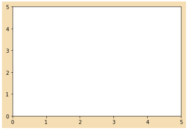

##### Multiple axes in a figure

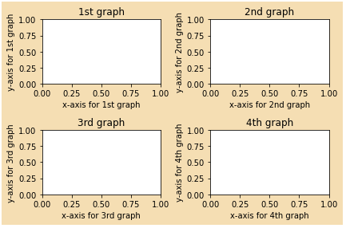

##### Plot on the axes

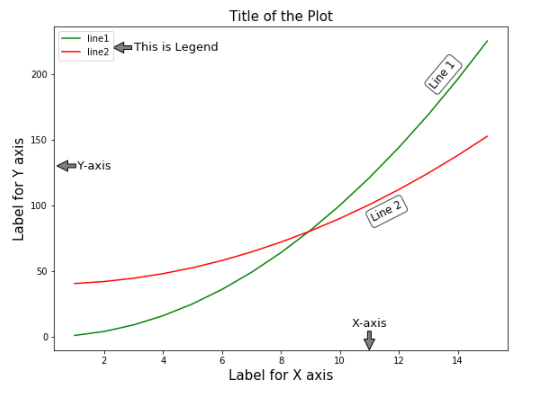

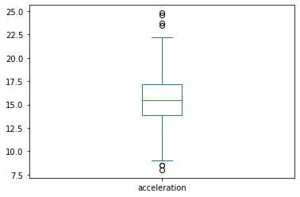

```python
# A boxplot gives a good indication of distribution of data about the median.
# Boxplots are a standardized way of displaying the distribution of data based
# on the five-number summary (“minimum”, first quartile (Q1), median, third quartile (Q3),
# and “maximum”).

cars_df['acceleration'].plot(kind='box')
```

**pandas.DataFrame.plot()** method helps to plot the columns in a DataFrame. Any plot created using this method is a Matplolib object. This method takes the parameter 'kind' which can be used to specify the type of plot like line, box, bar, scatter, pie etc.

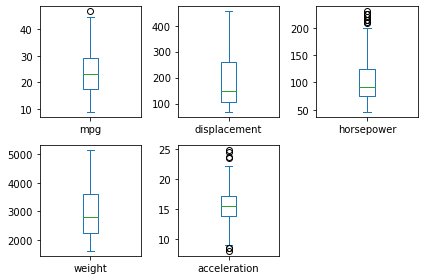

```python
# box-plot for all numerical columns of the DataFrame: cars_df
# plt.subplot(norows, ncols, plot_number)
# Plotting subplots On a grid of 2 rows x 3 columns

# box plot for mpg
plt.subplot(2,3,1)
cars_df['mpg'].plot(kind='box')

# box plot for displacement
plt.subplot(2,3,2)
cars_df['displacement'].plot(kind='box')

# box plot for horsepower
plt.subplot(2,3,3)
cars_df['horsepower'].plot(kind='box')

# box plot for horsepower
plt.subplot(2,3,4)
cars_df['weight'].plot(kind='box')

# box plot for acceleration
plt.subplot(2,3,5)
cars_df['acceleration'].plot(kind='box')

plt.tight_layout()
```

**matplotlib.pyplot.subplot()** method adds axes to the existing figure.

**matplotlib.pyplot.tight_layout()** method helps in adjusting the padding around subplots.

```python
cars_df[['mpg','displacement','horsepower','weight','acceleration']].describe()
```

|  | mpg | displacement | horsepower | weight | acceleration |
| --- | --- | --- | --- | --- | --- |
| count | 398.000000 | 398.000000 | 398.000000 | 398.000000 | 398.000000 |
| mean | 23.514573 | 193.425879 | 104.099083 | 2970.424623 | 15.568090 |
| std | 7.815984 | 104.269838 | 38.336173 | 846.841774 | 2.757689 |
| min | 9.000000 | 68.000000 | 46.000000 | 1613.000000 | 8.000000 |
| 25% | 17.500000 | 104.250000 | 75.000000 | 2223.750000 | 13.825000 |
| 50% | 23.000000 | 148.500000 | 92.000000 | 2803.500000 | 15.500000 |
| 75% | 29.000000 | 262.000000 | 125.000000 | 3608.000000 | 17.175000 |
| max | 46.600000 | 455.000000 | 230.000000 | 5140.000000 | 24.800000 |

##### Handling outliers in horespower and acceleration columns of the DataFrame: cars_df

```python
# finding the upper and lower limit of horespower and acceleration columns

def find_outlier_limits(col_name):
    Q1,Q3=cars_df[col_name].quantile([.25,.75])
    IQR=Q3-Q1
    low=Q1-(1.5* IQR)
    high=Q3+(1.5* IQR)
    return (high,low)

high_hp,low_hp=find_outlier_limits('horsepower')
print('Horsepower: ','upper limit: ',high_hp,' lower limit: ',low_hp)
high_acc,low_acc=find_outlier_limits('acceleration')
print('Acceleration: ','upper limit: ',high_acc,' lower limit:',low_acc)

# Replacing outlier values in horespower and acceleration columns with respective
# upper and lower limits

cars_df.loc[cars_df['horsepower']>high_hp,'horsepower']=high_hp
cars_df.loc[cars_df['acceleration']>high_acc,'acceleration']=high_acc
cars_df.loc[cars_df['acceleration']<low_acc,'acceleration']=low_acc
```

```
Horsepower:  upper limit:  200.0  lower limit:  0.0
Acceleration:  upper limit:  22.2  lower limit: 8.8
```

.loc and .iloc operators are used to select specific set of rows and columns in a DataFrame.

.loc operator can be used with row labels and column labels. Conditional expressions returning boolean can also be passed as row labels.

Example:**cars_df.loc[cars_df['mpg']<=10,'name']**

.iloc operator can be used with row positions and column positions

Example:**cars_df.iloc[10:20,0:3]**

.iloc operator can be used to filter rows based on conditional expressions

Example:**cars_df.iloc[cars_df.index[cars_df['cylinders']==3]]**

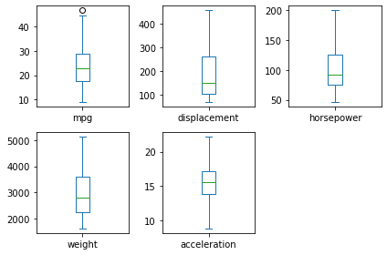

```python
# box-plot for all numerical columns of the DataFrame: cars_df
# plt.subplot(norows, ncols, plot_number)
# Plotting subplots On a grid of 2 rows x 3 columns

# box plot for mpg
plt.subplot(2,3,1)
cars_df['mpg'].plot(kind='box')

# box plot for displacement
plt.subplot(2,3,2)
cars_df['displacement'].plot(kind='box')

# box plot for horsepower
plt.subplot(2,3,3)
cars_df['horsepower'].plot(kind='box')

# box plot for horsepower
plt.subplot(2,3,4)
cars_df['weight'].plot(kind='box')

# box plot for acceleration
plt.subplot(2,3,5)
cars_df['acceleration'].plot(kind='box')

plt.tight_layout()
```

#### Day 2

### Data Understanding

- Q1: How many distinct cars have been serviced by RestoreManagers?
- Q2: Which company cars are serviced the most by RestoreMasters?
- Q3: What are the origins of the cars serviced?
- Q4: What is the distribution of the cars serviced based on origin?
- Q5: Which model year cars were serviced by RestoreMasters?
- Q6: What is the distribution of the cars serviced based on model year?
- Q7: Of the cars serviced by RestoreMasters, what was the cylinder types?
- Q8: What is the distribution of the cars serviced based on cylinder?
- Q9: How does the performance of the cars serviced vary based on cylinder?
- Q10: What trends can be observed for cars serviced in terms of model year and cylinders?
- Q11: What trends can be observed for cars serviced in terms of car origin and cylinders?
- Q12: What is the distribution of cars serviced in terms of model year and the car origin?
- Q13: What is the trend in car performance based on model year and origin?
- Q14: Does the weight, displacement, acceleration, horsepower affect the mileage of the car?
- Q15: What is the pattern in the weight, displacement, acceleration, horsepower, and mpg based on car type?

##### Q1: How many distinct cars have been serviced by RestoreManagers?

```python
cars_df
```

|  | mpg | cylinders | displacement | horsepower | weight | acceleration | model_year | origin | name |
| --- | --- | --- | --- | --- | --- | --- | --- | --- | --- |
| 0 | 18.0 | 8 | 307.0 | 130.0 | 3504 | 12.0 | 70 | usa | chevrolet chevelle malibu |
| 1 | 15.0 | 8 | 350.0 | 165.0 | 3693 | 11.5 | 70 | usa | buick skylark 320 |
| 2 | 18.0 | 8 | 318.0 | 150.0 | 3436 | 11.0 | 70 | usa | plymouth satellite |
| 3 | 16.0 | 8 | 304.0 | 150.0 | 3433 | 12.0 | 70 | usa | amc rebel sst |
| 4 | 17.0 | 8 | 302.0 | 140.0 | 3449 | 10.5 | 70 | usa | ford torino |
| ... | ... | ... | ... | ... | ... | ... | ... | ... | ... |
| 393 | 27.0 | 4 | 140.0 | 86.0 | 2790 | 15.6 | 82 | usa | ford mustang gl |
| 394 | 44.0 | 4 | 97.0 | 52.0 | 2130 | 22.2 | 82 | europe | vw pickup |
| 395 | 32.0 | 4 | 135.0 | 84.0 | 2295 | 11.6 | 82 | usa | dodge rampage |
| 396 | 28.0 | 4 | 120.0 | 79.0 | 2625 | 18.6 | 82 | usa | ford ranger |
| 397 | 31.0 | 4 | 119.0 | 82.0 | 2720 | 19.4 | 82 | usa | chevy s-10 |

398 rows × 9 columns

```python
# finding the names of the unique car serviced
cars_df['name'].unique()
```

```
array(['chevrolet chevelle malibu', 'buick skylark 320',
       'plymouth satellite', 'amc rebel sst', 'ford torino',
       'ford galaxie 500', 'chevrolet impala', 'plymouth fury iii',
       'pontiac catalina', 'amc ambassador dpl', 'dodge challenger se',
       "plymouth 'cuda 340", 'chevrolet monte carlo',
       'buick estate wagon (sw)', 'toyota corona mark ii',
       'plymouth duster', 'amc hornet', 'ford maverick', 'datsun pl510',
       'volkswagen 1131 deluxe sedan', 'peugeot 504', 'audi 100 ls',
       'saab 99e', 'bmw 2002', 'amc gremlin', 'ford f250', 'chevy c20',
       'dodge d200', 'hi 1200d', 'chevrolet vega 2300', 'toyota corona',
       'ford pinto', 'plymouth satellite custom', 'ford torino 500',
       'amc matador', 'pontiac catalina brougham', 'dodge monaco (sw)',
       'ford country squire (sw)', 'pontiac safari (sw)',
       'amc hornet sportabout (sw)', 'chevrolet vega (sw)',
       'pontiac firebird', 'ford mustang', 'mercury capri 2000',
       'opel 1900', 'peugeot 304', 'fiat 124b', 'toyota corolla 1200',
       'datsun 1200', 'volkswagen model 111', 'plymouth cricket',
       'toyota corona hardtop', 'dodge colt hardtop', 'volkswagen type 3',
       'chevrolet vega', 'ford pinto runabout', 'amc ambassador sst',
       'mercury marquis', 'buick lesabre custom',
       'oldsmobile delta 88 royale', 'chrysler newport royal',
       'mazda rx2 coupe', 'amc matador (sw)',
       'chevrolet chevelle concours (sw)', 'ford gran torino (sw)',
       'plymouth satellite custom (sw)', 'volvo 145e (sw)',
       'volkswagen 411 (sw)', 'peugeot 504 (sw)', 'renault 12 (sw)',
       'ford pinto (sw)', 'datsun 510 (sw)',
       'toyouta corona mark ii (sw)', 'dodge colt (sw)',
       'toyota corolla 1600 (sw)', 'buick century 350',
       'chevrolet malibu', 'ford gran torino', 'dodge coronet custom',
       'mercury marquis brougham', 'chevrolet caprice classic',
       'ford ltd', 'plymouth fury gran sedan',
       'chrysler new yorker brougham', 'buick electra 225 custom',
       'amc ambassador brougham', 'plymouth valiant',
       'chevrolet nova custom', 'volkswagen super beetle', 'ford country',
       'plymouth custom suburb', 'oldsmobile vista cruiser',
       'toyota carina', 'datsun 610', 'maxda rx3', 'mercury capri v6',
       'fiat 124 sport coupe', 'chevrolet monte carlo s',
       'pontiac grand prix', 'fiat 128', 'opel manta', 'audi 100ls',
       'volvo 144ea', 'dodge dart custom', 'saab 99le', 'toyota mark ii',
       'oldsmobile omega', 'chevrolet nova', 'datsun b210',
```

[output cut: 56 more lines]

```
       'ford escort 2h', 'volkswagen jetta', 'renault 18i',
       'honda prelude', 'datsun 200sx', 'peugeot 505s turbo diesel',
       'volvo diesel', 'toyota cressida', 'datsun 810 maxima',
       'oldsmobile cutlass ls', 'ford granada gl',
       'chrysler lebaron salon', 'chevrolet cavalier',
       'chevrolet cavalier wagon', 'chevrolet cavalier 2-door',
       'pontiac j2000 se hatchback', 'dodge aries se',
       'ford fairmont futura', 'amc concord dl', 'volkswagen rabbit l',
       'mazda glc custom l', 'mazda glc custom', 'plymouth horizon miser',
       'mercury lynx l', 'nissan stanza xe', 'honda civic (auto)',
       'datsun 310 gx', 'buick century limited',
       'oldsmobile cutlass ciera (diesel)', 'chrysler lebaron medallion',
       'ford granada l', 'toyota celica gt', 'dodge charger 2.2',
       'chevrolet camaro', 'ford mustang gl', 'vw pickup',
       'dodge rampage', 'ford ranger', 'chevy s-10'], dtype=object)
```

**pandas.Series.unique()** method returns the unique values in the series.

```python
# finding the number of unique car serviced
cars_df['name'].unique().size
```

```
305
```

##### Q2: Which company cars are serviced the most by RestoreMasters?

```python
cars_df
```

|  | mpg | cylinders | displacement | horsepower | weight | acceleration | model_year | origin | name |
| --- | --- | --- | --- | --- | --- | --- | --- | --- | --- |
| 0 | 18.0 | 8 | 307.0 | 130.0 | 3504 | 12.0 | 70 | usa | chevrolet chevelle malibu |
| 1 | 15.0 | 8 | 350.0 | 165.0 | 3693 | 11.5 | 70 | usa | buick skylark 320 |
| 2 | 18.0 | 8 | 318.0 | 150.0 | 3436 | 11.0 | 70 | usa | plymouth satellite |
| 3 | 16.0 | 8 | 304.0 | 150.0 | 3433 | 12.0 | 70 | usa | amc rebel sst |
| 4 | 17.0 | 8 | 302.0 | 140.0 | 3449 | 10.5 | 70 | usa | ford torino |
| ... | ... | ... | ... | ... | ... | ... | ... | ... | ... |
| 393 | 27.0 | 4 | 140.0 | 86.0 | 2790 | 15.6 | 82 | usa | ford mustang gl |
| 394 | 44.0 | 4 | 97.0 | 52.0 | 2130 | 22.2 | 82 | europe | vw pickup |
| 395 | 32.0 | 4 | 135.0 | 84.0 | 2295 | 11.6 | 82 | usa | dodge rampage |
| 396 | 28.0 | 4 | 120.0 | 79.0 | 2625 | 18.6 | 82 | usa | ford ranger |
| 397 | 31.0 | 4 | 119.0 | 82.0 | 2720 | 19.4 | 82 | usa | chevy s-10 |

398 rows × 9 columns

```python
# Extracting the company name from the name column
cars_df['company']=cars_df['name'].apply(lambda x:x.split()[0])
cars_df
```

|  | mpg | cylinders | displacement | horsepower | weight | acceleration | model_year | origin | name | company |
| --- | --- | --- | --- | --- | --- | --- | --- | --- | --- | --- |
| 0 | 18.0 | 8 | 307.0 | 130.0 | 3504 | 12.0 | 70 | usa | chevrolet chevelle malibu | chevrolet |
| 1 | 15.0 | 8 | 350.0 | 165.0 | 3693 | 11.5 | 70 | usa | buick skylark 320 | buick |
| 2 | 18.0 | 8 | 318.0 | 150.0 | 3436 | 11.0 | 70 | usa | plymouth satellite | plymouth |
| 3 | 16.0 | 8 | 304.0 | 150.0 | 3433 | 12.0 | 70 | usa | amc rebel sst | amc |
| 4 | 17.0 | 8 | 302.0 | 140.0 | 3449 | 10.5 | 70 | usa | ford torino | ford |
| ... | ... | ... | ... | ... | ... | ... | ... | ... | ... | ... |
| 393 | 27.0 | 4 | 140.0 | 86.0 | 2790 | 15.6 | 82 | usa | ford mustang gl | ford |
| 394 | 44.0 | 4 | 97.0 | 52.0 | 2130 | 22.2 | 82 | europe | vw pickup | vw |
| 395 | 32.0 | 4 | 135.0 | 84.0 | 2295 | 11.6 | 82 | usa | dodge rampage | dodge |
| 396 | 28.0 | 4 | 120.0 | 79.0 | 2625 | 18.6 | 82 | usa | ford ranger | ford |
| 397 | 31.0 | 4 | 119.0 | 82.0 | 2720 | 19.4 | 82 | usa | chevy s-10 | chevy |

398 rows × 10 columns

New columns can be created in a DataFrame by assigning the values to the DataFrame with new column name.

**cars_df['nameorigin'] = cars_df['name'] + ' ' + cars_df['origin']**

```python
# finding the number of unique companies
cars_df['company'].unique().size
```

```
37
```

```python
# get the names of the companies
cars_df['company'].unique()
```

```
array(['chevrolet', 'buick', 'plymouth', 'amc', 'ford', 'pontiac',
       'dodge', 'toyota', 'datsun', 'volkswagen', 'peugeot', 'audi',
       'saab', 'bmw', 'chevy', 'hi', 'mercury', 'opel', 'fiat',
       'oldsmobile', 'chrysler', 'mazda', 'volvo', 'renault', 'toyouta',
       'maxda', 'honda', 'subaru', 'chevroelt', 'capri', 'vw',
       'mercedes-benz', 'cadillac', 'mercedes', 'vokswagen', 'triumph',
       'nissan'], dtype=object)
```

```python
cars_df.groupby('company')[['name']].count()
```

| company | name |
| --- | --- |
| amc | 28 |
| audi | 7 |
| bmw | 2 |
| buick | 17 |
| cadillac | 2 |
| capri | 1 |
| chevroelt | 1 |
| chevrolet | 43 |
| chevy | 3 |
| chrysler | 6 |
| datsun | 23 |
| dodge | 28 |
| fiat | 8 |
| ford | 51 |
| hi | 1 |
| honda | 13 |
| maxda | 2 |
| mazda | 10 |
| mercedes | 1 |
| mercedes-benz | 2 |
| mercury | 11 |
| nissan | 1 |
| oldsmobile | 10 |
| opel | 4 |
| peugeot | 8 |
| plymouth | 31 |
| pontiac | 16 |
| renault | 5 |
| saab | 4 |
| subaru | 4 |
| toyota | 25 |
| toyouta | 1 |
| triumph | 1 |
| vokswagen | 1 |
| volkswagen | 15 |
| volvo | 6 |
| vw | 6 |

```python
# getting count of cars by company
company_count_df=cars_df.groupby('company')[['name']].count().sort_values('name',ascending=False).rename(columns={'name':'cars_count'})
company_count_df
```

| company | cars_count |
| --- | --- |
| ford | 51 |
| chevrolet | 43 |
| plymouth | 31 |
| amc | 28 |
| dodge | 28 |
| toyota | 25 |
| datsun | 23 |
| buick | 17 |
| pontiac | 16 |
| volkswagen | 15 |
| honda | 13 |
| mercury | 11 |
| oldsmobile | 10 |
| mazda | 10 |
| fiat | 8 |
| peugeot | 8 |
| audi | 7 |
| volvo | 6 |
| vw | 6 |
| chrysler | 6 |
| renault | 5 |
| saab | 4 |
| opel | 4 |
| subaru | 4 |
| chevy | 3 |
| maxda | 2 |
| bmw | 2 |
| cadillac | 2 |
| mercedes-benz | 2 |
| chevroelt | 1 |
| capri | 1 |
| toyouta | 1 |
| triumph | 1 |
| vokswagen | 1 |
| hi | 1 |
| nissan | 1 |
| mercedes | 1 |

**Pandas.DataFrame.sort_values()** method can be used to sort the data by column(s) in the DataFrame. By default, rows will be sorted in ascending order.

Example:**cars_df.sort_values('cylinders')**

Sorting data on multiple columns in descending order

Example:**cars_df.sort_values(['cylinders','model_year'],ascending=False)**

Example:**pandas.DataFrame.rename()** method can be used to rename the columns in the DataFrame.

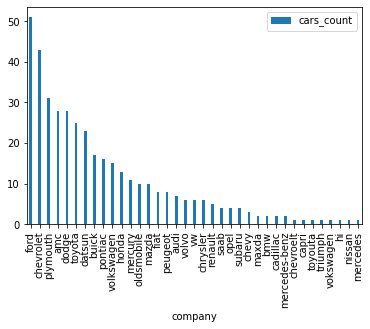

```python
# visualize company and car count (bar graph). A bar chart is a graph with rectangular bars
# that usually compare different categories. Each bar represents a particular category.
# The length of the bar indicates the total number of values or items in that category.

company_count_df.plot(kind='bar',width=0.3)
```

**Insight:** Ford company cars are serviced the most by RestoreMasters.

##### Q3: What are the origins of the cars serviced?

```python
cars_df
```

|  | mpg | cylinders | displacement | horsepower | weight | acceleration | model_year | origin | name | company |
| --- | --- | --- | --- | --- | --- | --- | --- | --- | --- | --- |
| 0 | 18.0 | 8 | 307.0 | 130.0 | 3504 | 12.0 | 70 | usa | chevrolet chevelle malibu | chevrolet |
| 1 | 15.0 | 8 | 350.0 | 165.0 | 3693 | 11.5 | 70 | usa | buick skylark 320 | buick |
| 2 | 18.0 | 8 | 318.0 | 150.0 | 3436 | 11.0 | 70 | usa | plymouth satellite | plymouth |
| 3 | 16.0 | 8 | 304.0 | 150.0 | 3433 | 12.0 | 70 | usa | amc rebel sst | amc |
| 4 | 17.0 | 8 | 302.0 | 140.0 | 3449 | 10.5 | 70 | usa | ford torino | ford |
| ... | ... | ... | ... | ... | ... | ... | ... | ... | ... | ... |
| 393 | 27.0 | 4 | 140.0 | 86.0 | 2790 | 15.6 | 82 | usa | ford mustang gl | ford |
| 394 | 44.0 | 4 | 97.0 | 52.0 | 2130 | 22.2 | 82 | europe | vw pickup | vw |
| 395 | 32.0 | 4 | 135.0 | 84.0 | 2295 | 11.6 | 82 | usa | dodge rampage | dodge |
| 396 | 28.0 | 4 | 120.0 | 79.0 | 2625 | 18.6 | 82 | usa | ford ranger | ford |
| 397 | 31.0 | 4 | 119.0 | 82.0 | 2720 | 19.4 | 82 | usa | chevy s-10 | chevy |

398 rows × 10 columns

```python
# getting the unique origins of the cars serviced
cars_df['origin'].unique()
```

```
['usa', 'japan', 'europe']
Categories (3, object): ['europe', 'japan', 'usa']
```

#### Q4: What is the distribution of the cars serviced based on origin?

```python
# getting count of cars by origin
origin_count_df=cars_df.groupby('origin')[['name']].count().sort_values('name',ascending=False).rename(columns={'name':'cars_count'})
origin_count_df
```

| origin | cars_count |
| --- | --- |
| usa | 249 |
| japan | 79 |
| europe | 70 |

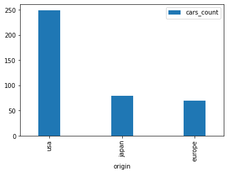

```python
# visualize origin and car count (bar graph)
origin_count_df.plot(kind='bar',width=0.3)
```

```python
# getting the percentage of cars serviced from USA

originwise_percent=((origin_count_df.loc['usa','cars_count']/cars_df.shape[0])*100)
originwise_percent
```

```
62.562814070351756
```

**Insight:** 62.5% of cars serviced by RestoreMasters are manufactured in USA

##### Q5: Which model year cars were serviced by RestoreMasters?

```python
cars_df
```

|  | mpg | cylinders | displacement | horsepower | weight | acceleration | model_year | origin | name | company |
| --- | --- | --- | --- | --- | --- | --- | --- | --- | --- | --- |
| 0 | 18.0 | 8 | 307.0 | 130.0 | 3504 | 12.0 | 70 | usa | chevrolet chevelle malibu | chevrolet |
| 1 | 15.0 | 8 | 350.0 | 165.0 | 3693 | 11.5 | 70 | usa | buick skylark 320 | buick |
| 2 | 18.0 | 8 | 318.0 | 150.0 | 3436 | 11.0 | 70 | usa | plymouth satellite | plymouth |
| 3 | 16.0 | 8 | 304.0 | 150.0 | 3433 | 12.0 | 70 | usa | amc rebel sst | amc |
| 4 | 17.0 | 8 | 302.0 | 140.0 | 3449 | 10.5 | 70 | usa | ford torino | ford |
| ... | ... | ... | ... | ... | ... | ... | ... | ... | ... | ... |
| 393 | 27.0 | 4 | 140.0 | 86.0 | 2790 | 15.6 | 82 | usa | ford mustang gl | ford |
| 394 | 44.0 | 4 | 97.0 | 52.0 | 2130 | 22.2 | 82 | europe | vw pickup | vw |
| 395 | 32.0 | 4 | 135.0 | 84.0 | 2295 | 11.6 | 82 | usa | dodge rampage | dodge |
| 396 | 28.0 | 4 | 120.0 | 79.0 | 2625 | 18.6 | 82 | usa | ford ranger | ford |
| 397 | 31.0 | 4 | 119.0 | 82.0 | 2720 | 19.4 | 82 | usa | chevy s-10 | chevy |

398 rows × 10 columns

```python
# getting the unique models of the cars serviced
cars_df['model_year'].unique()
```

```
array([70, 71, 72, 73, 74, 75, 76, 77, 78, 79, 80, 81, 82])
```

#### Q6: What is the distribution of the cars serviced based on model year?

```python
# getting count of cars by model year
model_count_df=cars_df.groupby('model_year')[['name']].count().rename(columns={'name':'cars_count'})
model_count_df
```

| model_year | cars_count |
| --- | --- |
| 70 | 29 |
| 71 | 28 |
| 72 | 28 |
| 73 | 40 |
| 74 | 27 |
| 75 | 30 |
| 76 | 34 |
| 77 | 28 |
| 78 | 36 |
| 79 | 29 |
| 80 | 29 |
| 81 | 29 |
| 82 | 31 |

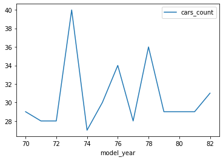

```python
# visualize Model Year and car count (bar graph)
model_count_df.plot(kind='line')
```

**Insight:** The year 73 model was serviced the maximum.

##### Q7: Of the cars serviced by RestoreMasters, what was the cylinder types?

```python
cars_df
```

|  | mpg | cylinders | displacement | horsepower | weight | acceleration | model_year | origin | name | company |
| --- | --- | --- | --- | --- | --- | --- | --- | --- | --- | --- |
| 0 | 18.0 | 8 | 307.0 | 130.0 | 3504 | 12.0 | 70 | usa | chevrolet chevelle malibu | chevrolet |
| 1 | 15.0 | 8 | 350.0 | 165.0 | 3693 | 11.5 | 70 | usa | buick skylark 320 | buick |
| 2 | 18.0 | 8 | 318.0 | 150.0 | 3436 | 11.0 | 70 | usa | plymouth satellite | plymouth |
| 3 | 16.0 | 8 | 304.0 | 150.0 | 3433 | 12.0 | 70 | usa | amc rebel sst | amc |
| 4 | 17.0 | 8 | 302.0 | 140.0 | 3449 | 10.5 | 70 | usa | ford torino | ford |
| ... | ... | ... | ... | ... | ... | ... | ... | ... | ... | ... |
| 393 | 27.0 | 4 | 140.0 | 86.0 | 2790 | 15.6 | 82 | usa | ford mustang gl | ford |
| 394 | 44.0 | 4 | 97.0 | 52.0 | 2130 | 22.2 | 82 | europe | vw pickup | vw |
| 395 | 32.0 | 4 | 135.0 | 84.0 | 2295 | 11.6 | 82 | usa | dodge rampage | dodge |
| 396 | 28.0 | 4 | 120.0 | 79.0 | 2625 | 18.6 | 82 | usa | ford ranger | ford |
| 397 | 31.0 | 4 | 119.0 | 82.0 | 2720 | 19.4 | 82 | usa | chevy s-10 | chevy |

398 rows × 10 columns

```python
# getting the unique cylinders of the cars serviced
cars_df['cylinders'].unique()
```

```
array([8, 4, 6, 3, 5])
```

**Insight:** The cars serviced by RestoreMasters also includes 3 and 5 cylinders which is uncommon

#### Q8: What is the distribution of the cars serviced based on cylinder?

```python
# getting count of cars by cylinders
cylinder_count_df=cars_df.groupby('cylinders')[['name']].count().rename(columns={'name':'cars_count'})
cylinder_count_df
```

| cylinders | cars_count |
| --- | --- |
| 3 | 4 |
| 4 | 204 |
| 5 | 3 |
| 6 | 84 |
| 8 | 103 |

```python
# getting the percentage of cars serviced with 4 cylinders

cylinderwise_percent=((cylinder_count_df.loc[4][0]/cars_df.shape[0])*100)
cylinderwise_percent
```

```
51.256281407035175
```

**Insight:** 51.26% of cars serviced by RestoreMasters are of 4 cylinders

```python
# filtering cars with 3 or 5 cylinders
cars_df[(cars_df['cylinders']==3) | (cars_df['cylinders']==5)][['origin','model_year','name','company','cylinders']]
```

|  | origin | model_year | name | company | cylinders |
| --- | --- | --- | --- | --- | --- |
| 71 | japan | 72 | mazda rx2 coupe | mazda | 3 |
| 111 | japan | 73 | maxda rx3 | maxda | 3 |
| 243 | japan | 77 | mazda rx-4 | mazda | 3 |
| 274 | europe | 78 | audi 5000 | audi | 5 |
| 297 | europe | 79 | mercedes benz 300d | mercedes | 5 |
| 327 | europe | 80 | audi 5000s (diesel) | audi | 5 |
| 334 | japan | 80 | mazda rx-7 gs | mazda | 3 |

**Insight:** The cars with 3 cylinders are only manufactured in Japan. The cars with 5 cylinders are only manufactured in Europe

#### Q9: How does the performance of the cars serviced vary based on cylinder?

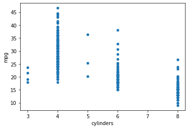

```python
# A scatter plot helps to observe the relationship between variables.
# Scatter plot between cylinders and mpg columns of the DataFrame: cars_df
cars_df.plot(x='cylinders',y='mpg', kind='scatter')
```

**Insight:** As the cylinders increases the mpg decreases. The only exception is when cylinders are increased from 3 to 4.

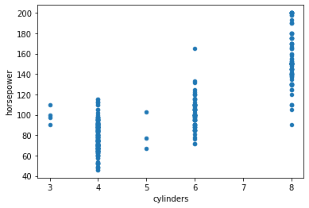

```python
# Scatter plot between cylinders and horsepower columns of the DataFrame: cars_df
cars_df.plot(x='cylinders',y='horsepower', kind='scatter')
```

#### Q10: What trends can be observed for cars serviced in terms of model year and cylinders?

```python
cars_df.groupby(['model_year','cylinders'])[['name']].count()
```

| model_year | cylinders | name |
| --- | --- | --- |
| 70 | 4 | 7 |
|  | 6 | 4 |
|  | 8 | 18 |
| 71 | 4 | 13 |
|  | 6 | 8 |
|  | 8 | 7 |
| 72 | 3 | 1 |
|  | 4 | 14 |
|  | 8 | 13 |
| 73 | 3 | 1 |
|  | 4 | 11 |
|  | 6 | 8 |
|  | 8 | 20 |
| 74 | 4 | 15 |
|  | 6 | 7 |
|  | 8 | 5 |
| 75 | 4 | 12 |
|  | 6 | 12 |
|  | 8 | 6 |
| 76 | 4 | 15 |
|  | 6 | 10 |
|  | 8 | 9 |
| 77 | 3 | 1 |
|  | 4 | 14 |
|  | 6 | 5 |
|  | 8 | 8 |
| 78 | 4 | 17 |
|  | 5 | 1 |
|  | 6 | 12 |
|  | 8 | 6 |
| 79 | 4 | 12 |
|  | 5 | 1 |
|  | 6 | 6 |
|  | 8 | 10 |
| 80 | 3 | 1 |
|  | 4 | 25 |
|  | 5 | 1 |
|  | 6 | 2 |
| 81 | 4 | 21 |
|  | 6 | 7 |
|  | 8 | 1 |
| 82 | 4 | 28 |
|  | 6 | 3 |

```python
# Trends by Model Year and cylinders
model_cylinder_df=cars_df.groupby(['model_year','cylinders'])[['name']].count().rename(columns={'name':'cars_count'})
model_cylinder_df
```

| model_year | cylinders | cars_count |
| --- | --- | --- |
| 70 | 4 | 7 |
|  | 6 | 4 |
|  | 8 | 18 |
| 71 | 4 | 13 |
|  | 6 | 8 |
|  | 8 | 7 |
| 72 | 3 | 1 |
|  | 4 | 14 |
|  | 8 | 13 |
| 73 | 3 | 1 |
|  | 4 | 11 |
|  | 6 | 8 |
|  | 8 | 20 |
| 74 | 4 | 15 |
|  | 6 | 7 |
|  | 8 | 5 |
| 75 | 4 | 12 |
|  | 6 | 12 |
|  | 8 | 6 |
| 76 | 4 | 15 |
|  | 6 | 10 |
|  | 8 | 9 |
| 77 | 3 | 1 |
|  | 4 | 14 |
|  | 6 | 5 |
|  | 8 | 8 |
| 78 | 4 | 17 |
|  | 5 | 1 |
|  | 6 | 12 |
|  | 8 | 6 |
| 79 | 4 | 12 |
|  | 5 | 1 |
|  | 6 | 6 |
|  | 8 | 10 |
| 80 | 3 | 1 |
|  | 4 | 25 |
|  | 5 | 1 |
|  | 6 | 2 |
| 81 | 4 | 21 |
|  | 6 | 7 |
|  | 8 | 1 |
| 82 | 4 | 28 |
|  | 6 | 3 |

```python
model_cylinder_df.reset_index(inplace=True)
```

```python
model_cylinder_df
```

|  | model_year | cylinders | cars_count |
| --- | --- | --- | --- |
| 0 | 70 | 4 | 7 |
| 1 | 70 | 6 | 4 |
| 2 | 70 | 8 | 18 |
| 3 | 71 | 4 | 13 |
| 4 | 71 | 6 | 8 |
| 5 | 71 | 8 | 7 |
| 6 | 72 | 3 | 1 |
| 7 | 72 | 4 | 14 |
| 8 | 72 | 8 | 13 |
| 9 | 73 | 3 | 1 |
| 10 | 73 | 4 | 11 |
| 11 | 73 | 6 | 8 |
| 12 | 73 | 8 | 20 |
| 13 | 74 | 4 | 15 |
| 14 | 74 | 6 | 7 |
| 15 | 74 | 8 | 5 |
| 16 | 75 | 4 | 12 |
| 17 | 75 | 6 | 12 |
| 18 | 75 | 8 | 6 |
| 19 | 76 | 4 | 15 |
| 20 | 76 | 6 | 10 |
| 21 | 76 | 8 | 9 |
| 22 | 77 | 3 | 1 |
| 23 | 77 | 4 | 14 |
| 24 | 77 | 6 | 5 |
| 25 | 77 | 8 | 8 |
| 26 | 78 | 4 | 17 |
| 27 | 78 | 5 | 1 |
| 28 | 78 | 6 | 12 |
| 29 | 78 | 8 | 6 |
| 30 | 79 | 4 | 12 |
| 31 | 79 | 5 | 1 |
| 32 | 79 | 6 | 6 |
| 33 | 79 | 8 | 10 |
| 34 | 80 | 3 | 1 |
| 35 | 80 | 4 | 25 |
| 36 | 80 | 5 | 1 |
| 37 | 80 | 6 | 2 |
| 38 | 81 | 4 | 21 |
| 39 | 81 | 6 | 7 |
| 40 | 81 | 8 | 1 |
| 41 | 82 | 4 | 28 |
| 42 | 82 | 6 | 3 |

**pandas.DataFrame.reset_index()** method is used to reset the index of the DataFrame to default index(0, 1, 2, ... ) and add the existing index as a new column to the DataFrame.

```python
model_pivot=pd.pivot_table(model_cylinder_df[['model_year','cylinders','cars_count']], index='model_year', columns='cylinders', values='cars_count', aggfunc=np.sum)
model_pivot
```

| cylinders model_year | 3 | 4 | 5 | 6 | 8 |
| --- | --- | --- | --- | --- | --- |
| 70 | NaN | 7.0 | NaN | 4.0 | 18.0 |
| 71 | NaN | 13.0 | NaN | 8.0 | 7.0 |
| 72 | 1.0 | 14.0 | NaN | NaN | 13.0 |
| 73 | 1.0 | 11.0 | NaN | 8.0 | 20.0 |
| 74 | NaN | 15.0 | NaN | 7.0 | 5.0 |
| 75 | NaN | 12.0 | NaN | 12.0 | 6.0 |
| 76 | NaN | 15.0 | NaN | 10.0 | 9.0 |
| 77 | 1.0 | 14.0 | NaN | 5.0 | 8.0 |
| 78 | NaN | 17.0 | 1.0 | 12.0 | 6.0 |
| 79 | NaN | 12.0 | 1.0 | 6.0 | 10.0 |
| 80 | 1.0 | 25.0 | 1.0 | 2.0 | NaN |
| 81 | NaN | 21.0 | NaN | 7.0 | 1.0 |
| 82 | NaN | 28.0 | NaN | 3.0 | NaN |

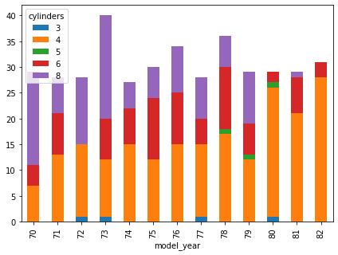

```python
model_pivot.plot(kind='bar', stacked='True',figsize=(7,5))
```

**pandas.DataFrame.pivot_table()** is similar to spread-sheet pivot tables, which helps in modifying the shape of the table for aggregating and analyzing the data in the DataFrame

**Insights:**

1. The later model year cars have less number of cylinders.
2. Throughtout the model years, 4 cylinder cars are in significant proportion.

#### Q11: What trends can be observed for cars serviced in terms of car origin and the cylinders?

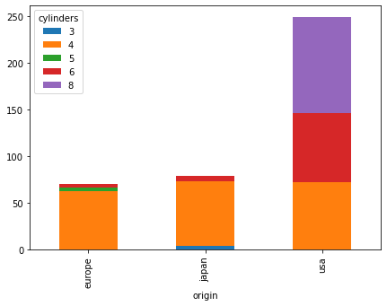

```python
# Trends by origin and cylinders
origin_cylinder_df=cars_df.groupby(['origin','cylinders'])[['name']].count().rename(columns={'name':'cars_count'})
origin_cylinder_df.reset_index(inplace=True)
origin_pivot=pd.pivot_table(origin_cylinder_df[['origin','cylinders','cars_count']], index='origin', columns='cylinders', values='cars_count', aggfunc=np.sum)
origin_pivot.plot(kind='bar', stacked='True',figsize=(7,5))
```

**Insights:**

1. All 8 cylinder cars serviced are manufactured in USA
2. 6 cylinder cars serviced are prominently manufactured in USA
3. 4 cylinder cars serviced are equally manufactured in every origin
4. All 3 cylinder cars serviced are manufactured in Japan
5. All 5 cylinder cars serviced are manufactured in Europe

#### Q12: What is the distribution of cars serviced in terms of model year and the car origin?

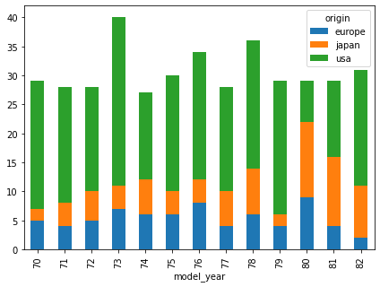

```python
# Trends by Model year and origin

model_origin_df=cars_df.groupby(['model_year','origin'])[['name']].count().rename(columns={'name':'cars_count'})
model_origin_df.reset_index(inplace=True)
modorg_pivot=pd.pivot_table(model_origin_df[['model_year','origin','cars_count']], index='model_year', columns='origin', values='cars_count', aggfunc=np.sum)
modorg_pivot.plot(kind='bar', stacked='True',figsize=(7,5))
```

**Insights:**

1. Most of early model year cars are manufactured in USA
2. Later model year cars are manufactured in Japan and Europe especially in model year 80.

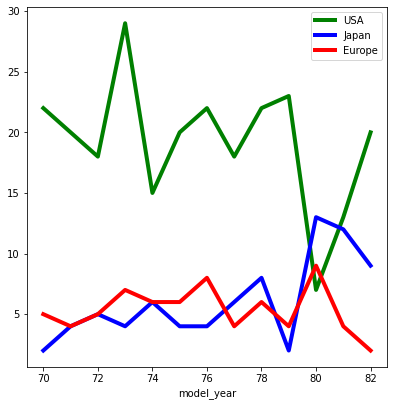

```python
model_origin_df=cars_df.groupby(['model_year','origin'])[['name']].count().reset_index().rename(columns={'name':'cars_count'})
# visualize origin wise - year and car_count (line)
#creating an empty canvas/figure
fig = plt.figure(figsize=[5,5]) #figsize represents width and height in inches. Default value is [6.4, 4.8]
#Adding single axes to the figure
ax1 = fig.add_axes([0, 0, 1, 1]) #The dimensions [left, bottom, width, height] of the new Axes with respect to figure size
model_origin_df[model_origin_df['origin']=='usa'].plot( ax=ax1, x = "model_year", y = "cars_count",kind = "line",color='green', linewidth=4, label='USA' )
model_origin_df[model_origin_df['origin']=='japan'].plot(ax=ax1, x = "model_year", y = "cars_count",kind = "line",color='blue', linewidth=4, label='Japan' )
model_origin_df[model_origin_df['origin']=='europe'].plot(ax=ax1, x = "model_year", y = "cars_count",kind = "line",color='red', linewidth=4, label='Europe' )
plt.legend()
```

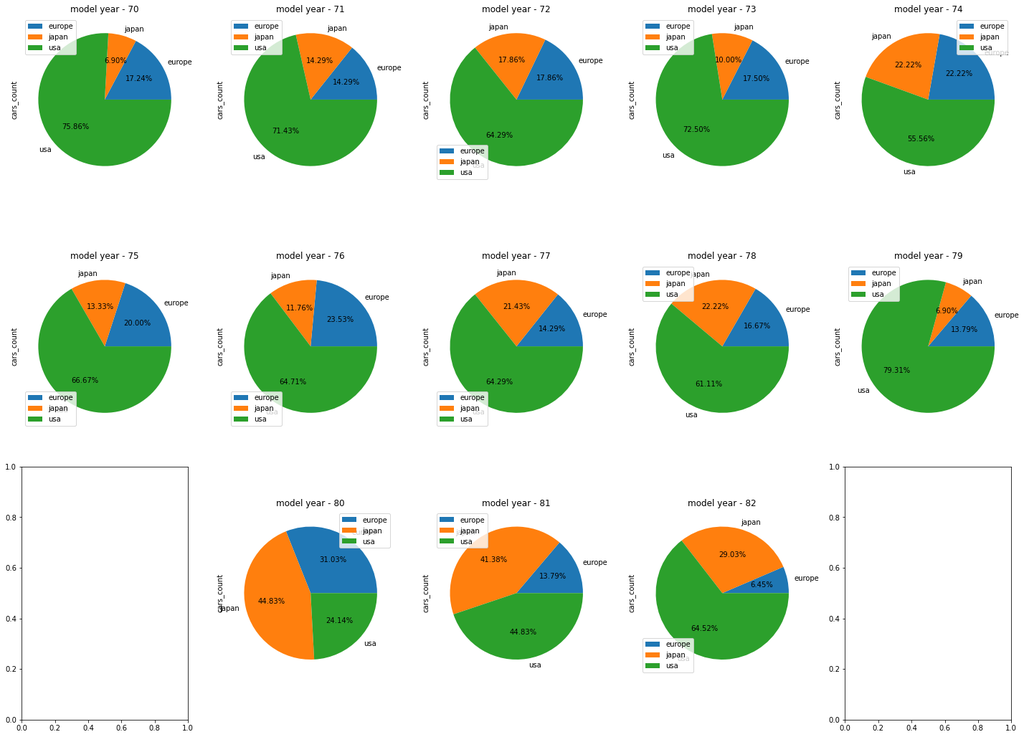

```python
# visualize yearwise - origin and car_count (pie)
# visual representation of empty sub plots
fig,ax=plt.subplots(3,5,figsize=(20,15))
ax[0][0].set_title('model year - 70')
model_origin_df[model_origin_df['model_year']==70].plot(kind='pie',labels=model_origin_df[model_origin_df['model_year']==70]['origin'], y='cars_count',ax=ax[0][0],autopct='%.2f%%')
ax[0][1].set_title('model year - 71')
model_origin_df[model_origin_df['model_year']==71].plot(kind='pie',labels=model_origin_df[model_origin_df['model_year']==71]['origin'], y='cars_count',ax=ax[0][1],autopct='%.2f%%')
ax[0][2].set_title('model year - 72')
model_origin_df[model_origin_df['model_year']==72].plot(kind='pie',labels=model_origin_df[model_origin_df['model_year']==72]['origin'], y='cars_count',ax=ax[0][2],autopct='%.2f%%')
ax[0][3].set_title('model year - 73')
model_origin_df[model_origin_df['model_year']==73].plot(kind='pie',labels=model_origin_df[model_origin_df['model_year']==73]['origin'], y='cars_count',ax=ax[0][3],autopct='%.2f%%')
ax[0][4].set_title('model year - 74')
model_origin_df[model_origin_df['model_year']==74].plot(kind='pie',labels=model_origin_df[model_origin_df['model_year']==74]['origin'], y='cars_count',ax=ax[0][4],autopct='%.2f%%')
ax[1][0].set_title('model year - 75')
model_origin_df[model_origin_df['model_year']==75].plot(kind='pie',labels=model_origin_df[model_origin_df['model_year']==75]['origin'], y='cars_count',ax=ax[1][0],autopct='%.2f%%')
ax[1][1].set_title('model year - 76')
model_origin_df[model_origin_df['model_year']==76].plot(kind='pie',labels=model_origin_df[model_origin_df['model_year']==76]['origin'], y='cars_count',ax=ax[1][1],autopct='%.2f%%')
ax[1][2].set_title('model year - 77')
model_origin_df[model_origin_df['model_year']==77].plot(kind='pie',labels=model_origin_df[model_origin_df['model_year']==77]['origin'], y='cars_count',ax=ax[1][2],autopct='%.2f%%')
ax[1][3].set_title('model year - 78')
model_origin_df[model_origin_df['model_year']==78].plot(kind='pie',labels=model_origin_df[model_origin_df['model_year']==78]['origin'], y='cars_count',ax=ax[1][3],autopct='%.2f%%')
ax[1][4].set_title('model year - 79')
model_origin_df[model_origin_df['model_year']==79].plot(kind='pie',labels=model_origin_df[model_origin_df['model_year']==79]['origin'], y='cars_count',ax=ax[1][4],autopct='%.2f%%')
ax[2][1].set_title('model year - 80')
model_origin_df[model_origin_df['model_year']==80].plot(kind='pie',labels=model_origin_df[model_origin_df['model_year']==80]['origin'], y='cars_count',ax=ax[2][1],autopct='%.2f%%')
ax[2][2].set_title('model year - 81')
model_origin_df[model_origin_df['model_year']==81].plot(kind='pie',labels=model_origin_df[model_origin_df['model_year']==81]['origin'], y='cars_count',ax=ax[2][2],autopct='%.2f%%')
ax[2][3].set_title('model year - 82')
model_origin_df[model_origin_df['model_year']==82].plot(kind='pie',labels=model_origin_df[model_origin_df['model_year']==82]['origin'], y='cars_count',ax=ax[2][3],autopct='%.2f%%')
plt.tight_layout()
```

**matplotlib.pyplot.subplots()** methods creates a figure and set of axes.

#### Q13: What is the trend in car performance based on model year and origin?

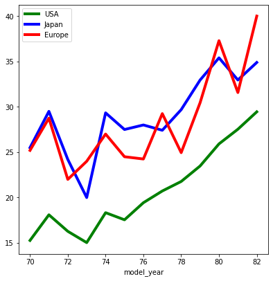

```python
# origin, year, mean mpg - line graph
mpg_df=cars_df.groupby(['origin','model_year'])[['mpg']].mean().reset_index()
fig = plt.figure(figsize=[5,5])
ax = fig.add_axes([0, 0, 1, 1])
mpg_df[mpg_df['origin']=='usa'].plot( ax=ax, x = "model_year", y = "mpg",kind = "line",color='green', linewidth=4, label='USA' )
mpg_df[mpg_df['origin']=='japan'].plot(ax=ax, x = "model_year", y = "mpg",kind = "line",color='blue', linewidth=4, label='Japan' )
mpg_df[mpg_df['origin']=='europe'].plot(ax=ax, x = "model_year", y = "mpg",kind = "line",color='red', linewidth=4, label='Europe' )
plt.legend()
```

**Insights:**

1. Cars manufactured in USA have lesser average mileage when compared to Japan and Europe. This is because, USA contributes to 62.5% of the cars.
2. As the model year increases, the average mileage of cars manufactured in all origin increases.

```python
# for every origin, min max and mean mpg across model years
cars_df['origin']=cars_df['origin'].astype('object')
mpg_pivot=pd.pivot_table(cars_df, values ='mpg', index ='model_year', columns ='origin', aggfunc = [np.mean, np.max, np.min])
mpg_pivot
```

| origin model_year | mean europe | mean japan | mean usa | amax europe | amax japan | amax usa | amin europe | amin japan | amin usa |
| --- | --- | --- | --- | --- | --- | --- | --- | --- | --- |
| 70 | 25.200000 | 25.500000 | 15.272727 | 26.0 | 27.0 | 22.0 | 24.0 | 24.0 | 9.0 |
| 71 | 28.750000 | 29.500000 | 18.100000 | 30.0 | 35.0 | 28.0 | 27.0 | 25.0 | 12.0 |
| 72 | 22.000000 | 24.200000 | 16.277778 | 26.0 | 28.0 | 28.0 | 18.0 | 19.0 | 11.0 |
| 73 | 24.000000 | 20.000000 | 15.034483 | 29.0 | 22.0 | 23.0 | 19.0 | 18.0 | 11.0 |
| 74 | 27.000000 | 29.333333 | 18.333333 | 31.0 | 32.0 | 28.0 | 24.0 | 24.0 | 13.0 |
| 75 | 24.500000 | 27.500000 | 17.550000 | 29.0 | 33.0 | 23.0 | 22.0 | 24.0 | 13.0 |
| 76 | 24.250000 | 28.000000 | 19.431818 | 29.5 | 33.0 | 29.0 | 16.5 | 19.0 | 13.0 |
| 77 | 29.250000 | 27.416667 | 20.722222 | 36.0 | 33.5 | 33.5 | 21.5 | 21.5 | 15.0 |
| 78 | 24.950000 | 29.687500 | 21.772727 | 43.1 | 39.4 | 36.1 | 16.2 | 21.1 | 17.5 |
| 79 | 30.450000 | 32.950000 | 23.478261 | 37.3 | 34.1 | 35.7 | 25.4 | 31.8 | 15.5 |
| 80 | 37.288889 | 35.400000 | 25.914286 | 44.3 | 46.6 | 32.1 | 29.8 | 23.7 | 19.1 |
| 81 | 31.575000 | 32.958333 | 27.530769 | 34.5 | 39.1 | 39.0 | 28.1 | 24.2 | 17.6 |
| 82 | 40.000000 | 34.888889 | 29.450000 | 44.0 | 38.0 | 38.0 | 36.0 | 31.0 | 22.0 |

```python
mpg_pivot.reset_index(inplace=True)
mpg_pivot
```

| origin | model_year | mean europe | mean japan | mean usa | amax europe | amax japan | amax usa | amin europe | amin japan | amin usa |
| --- | --- | --- | --- | --- | --- | --- | --- | --- | --- | --- |
| 0 | 70 | 25.200000 | 25.500000 | 15.272727 | 26.0 | 27.0 | 22.0 | 24.0 | 24.0 | 9.0 |
| 1 | 71 | 28.750000 | 29.500000 | 18.100000 | 30.0 | 35.0 | 28.0 | 27.0 | 25.0 | 12.0 |
| 2 | 72 | 22.000000 | 24.200000 | 16.277778 | 26.0 | 28.0 | 28.0 | 18.0 | 19.0 | 11.0 |
| 3 | 73 | 24.000000 | 20.000000 | 15.034483 | 29.0 | 22.0 | 23.0 | 19.0 | 18.0 | 11.0 |
| 4 | 74 | 27.000000 | 29.333333 | 18.333333 | 31.0 | 32.0 | 28.0 | 24.0 | 24.0 | 13.0 |
| 5 | 75 | 24.500000 | 27.500000 | 17.550000 | 29.0 | 33.0 | 23.0 | 22.0 | 24.0 | 13.0 |
| 6 | 76 | 24.250000 | 28.000000 | 19.431818 | 29.5 | 33.0 | 29.0 | 16.5 | 19.0 | 13.0 |
| 7 | 77 | 29.250000 | 27.416667 | 20.722222 | 36.0 | 33.5 | 33.5 | 21.5 | 21.5 | 15.0 |
| 8 | 78 | 24.950000 | 29.687500 | 21.772727 | 43.1 | 39.4 | 36.1 | 16.2 | 21.1 | 17.5 |
| 9 | 79 | 30.450000 | 32.950000 | 23.478261 | 37.3 | 34.1 | 35.7 | 25.4 | 31.8 | 15.5 |
| 10 | 80 | 37.288889 | 35.400000 | 25.914286 | 44.3 | 46.6 | 32.1 | 29.8 | 23.7 | 19.1 |
| 11 | 81 | 31.575000 | 32.958333 | 27.530769 | 34.5 | 39.1 | 39.0 | 28.1 | 24.2 | 17.6 |
| 12 | 82 | 40.000000 | 34.888889 | 29.450000 | 44.0 | 38.0 | 38.0 | 36.0 | 31.0 | 22.0 |

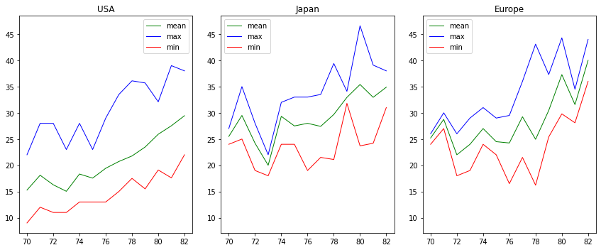

```python
plt.figure(figsize=(12,5))
ax1=plt.subplot(1,3,1)
plt.title('USA')
plt.plot(mpg_pivot['model_year'], mpg_pivot['mean']['usa'],color='green', linewidth=1, label='mean' )
plt.plot(mpg_pivot['model_year'], mpg_pivot['amax']['usa'],color='blue', linewidth=1, label='max' )
plt.plot(mpg_pivot['model_year'], mpg_pivot['amin']['usa'],color='red', linewidth=1, label='min' )
plt.legend()
plt.subplot(1,3,2, sharey=ax1)
plt.title('Japan')
plt.plot(mpg_pivot['model_year'], mpg_pivot['mean']['japan'],color='green', linewidth=1, label='mean' )
plt.plot(mpg_pivot['model_year'], mpg_pivot['amax']['japan'],color='blue', linewidth=1, label='max' )
plt.plot(mpg_pivot['model_year'], mpg_pivot['amin']['japan'],color='red', linewidth=1, label='min' )
plt.legend()
plt.subplot(1,3,3, sharey=ax1)
plt.title('Europe')
plt.plot(mpg_pivot['model_year'], mpg_pivot['mean']['europe'],color='green', linewidth=1, label='mean' )
plt.plot(mpg_pivot['model_year'], mpg_pivot['amax']['europe'],color='blue', linewidth=1, label='max' )
plt.plot(mpg_pivot['model_year'], mpg_pivot['amin']['europe'],color='red', linewidth=1, label='min' )
plt.legend()
plt.tight_layout()
```

**Insights:**

1. cars manufactured in Japan has maximum mileage
2. Cars manufactured in USA have minimum mileage as cars are largely of 6 and 8 cylinders

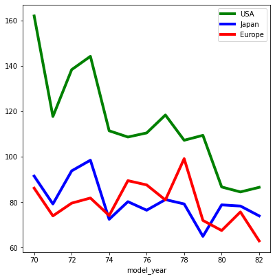

```python
# origin, year, mean horsepower - line graph
mpg_df=cars_df.groupby(['origin','model_year'])[['horsepower']].mean().reset_index()
fig = plt.figure(figsize=[5,5])
ax = fig.add_axes([0, 0, 1, 1])
mpg_df[mpg_df['origin']=='usa'].plot( ax=ax, x = "model_year", y = "horsepower",kind = "line",color='green', linewidth=4, label='USA' )
mpg_df[mpg_df['origin']=='japan'].plot(ax=ax, x = "model_year", y = "horsepower",kind = "line",color='blue', linewidth=4, label='Japan' )
mpg_df[mpg_df['origin']=='europe'].plot(ax=ax, x = "model_year", y = "horsepower",kind = "line",color='red', linewidth=4, label='Europe' )
plt.legend()
```

**Insights:**

1. Cars from USA have reduced horsepower as they are having less number of cylinders in later models
2. Cars from USA have higher horsepower when compared to Japan and Europe

#### Q14: Does the weight, displacement, acceleration, horsepower affect the mileage of the car?

```python
# correlation
correlation_df=cars_df[['mpg','displacement','horsepower','weight','acceleration']].corr()
correlation_df
```

|  | mpg | displacement | horsepower | weight | acceleration |
| --- | --- | --- | --- | --- | --- |
| mpg | 1.000000 | -0.804203 | -0.787786 | -0.831741 | 0.418293 |
| displacement | -0.804203 | 1.000000 | 0.901515 | 0.932824 | -0.548667 |
| horsepower | -0.787786 | 0.901515 | 1.000000 | 0.874652 | -0.693798 |
| weight | -0.831741 | 0.932824 | 0.874652 | 1.000000 | -0.422492 |
| acceleration | 0.418293 | -0.548667 | -0.693798 | -0.422492 | 1.000000 |

**pandas.DataFrame.corr()** method calculates the pairwise correlation of columns.

Correlation scores helps in defining the linear relationship between the two columns. Coorrelation is measured using correlation coefficient.

- Positive values of correlation coefficient indicate that the values of both columns tend to increase together resulting in Positive correlation
- Negative values of correlation coefficient indicate that when values of one column increases, the values of other decreases resulting in Negative correlation.

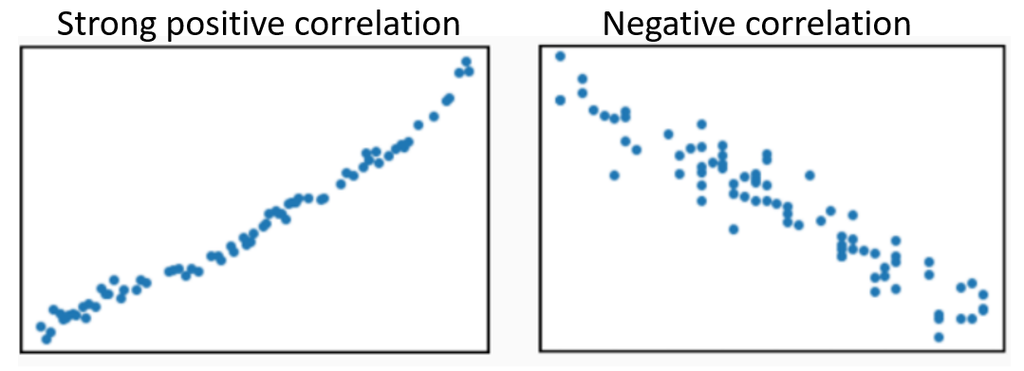

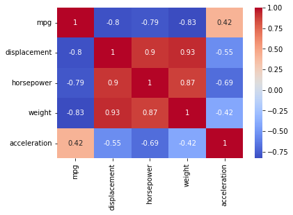

```python
# correlation between numerical columns
import seaborn as sns
sns.heatmap(correlation_df, cmap="coolwarm", annot=True)
```

**Insights:**: All the columns except acceleration are highly correlated.

#### Q15: What is the pattern in the weight, displacement, acceleration, horsepower, and mpg based on car type?

```python
# based on mpg and cylinders, creating a new column - car_type (hatchback, sedan, SUV, sports)

cars_df.loc[(cars_df['cylinders']==3),'car_type']='Hatchback'
cars_df.loc[(cars_df['cylinders']==4) & (cars_df['mpg']>=30),'car_type']='Hatchback'
cars_df.loc[(cars_df['cylinders']==5),'car_type']='Sedan'
cars_df.loc[(cars_df['cylinders']==4) & (cars_df['mpg']<30),'car_type']='Sedan'
cars_df.loc[(cars_df['cylinders']==6),'car_type']='SUV'
cars_df.loc[(cars_df['cylinders']==8),'car_type']='Sports'
cars_df
```

|  | mpg | cylinders | displacement | horsepower | weight | acceleration | model_year | origin | name | company | car_type |
| --- | --- | --- | --- | --- | --- | --- | --- | --- | --- | --- | --- |
| 0 | 18.0 | 8 | 307.0 | 130.0 | 3504 | 12.0 | 70 | usa | chevrolet chevelle malibu | chevrolet | Sports |
| 1 | 15.0 | 8 | 350.0 | 165.0 | 3693 | 11.5 | 70 | usa | buick skylark 320 | buick | Sports |
| 2 | 18.0 | 8 | 318.0 | 150.0 | 3436 | 11.0 | 70 | usa | plymouth satellite | plymouth | Sports |
| 3 | 16.0 | 8 | 304.0 | 150.0 | 3433 | 12.0 | 70 | usa | amc rebel sst | amc | Sports |
| 4 | 17.0 | 8 | 302.0 | 140.0 | 3449 | 10.5 | 70 | usa | ford torino | ford | Sports |
| ... | ... | ... | ... | ... | ... | ... | ... | ... | ... | ... | ... |
| 393 | 27.0 | 4 | 140.0 | 86.0 | 2790 | 15.6 | 82 | usa | ford mustang gl | ford | Sedan |
| 394 | 44.0 | 4 | 97.0 | 52.0 | 2130 | 22.2 | 82 | europe | vw pickup | vw | Hatchback |
| 395 | 32.0 | 4 | 135.0 | 84.0 | 2295 | 11.6 | 82 | usa | dodge rampage | dodge | Hatchback |
| 396 | 28.0 | 4 | 120.0 | 79.0 | 2625 | 18.6 | 82 | usa | ford ranger | ford | Sedan |
| 397 | 31.0 | 4 | 119.0 | 82.0 | 2720 | 19.4 | 82 | usa | chevy s-10 | chevy | Hatchback |

398 rows × 11 columns

```python
# number of cars under each type
cars_df.groupby('car_type')[['name']].count()
```

| car_type | name |
| --- | --- |
| Hatchback | 92 |
| SUV | 84 |
| Sedan | 119 |
| Sports | 103 |

```python
# mean metrics of different car types
metrics_df=cars_df.groupby('car_type')[['mpg','displacement','horsepower','weight','acceleration']].mean().sort_values('mpg',ascending=False)
metrics_df
```

| car_type | mpg | displacement | horsepower | weight | acceleration |
| --- | --- | --- | --- | --- | --- |
| Hatchback | 34.028261 | 97.097826 | 71.184712 | 2128.521739 | 16.476087 |
| Sedan | 25.278992 | 119.247899 | 84.460294 | 2470.067227 | 16.571429 |
| SUV | 19.985714 | 218.142857 | 101.507937 | 3198.226190 | 16.263095 |
| Sports | 14.963107 | 345.009709 | 156.475728 | 4114.718447 | 12.968932 |

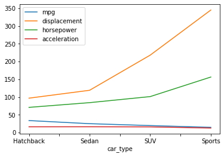

```python
# multiple line graph
metrics_df[['mpg','displacement','horsepower','acceleration']].plot()
```

**Insights:**

1. Sports cars have lesser acceleration time
2. Hatchback cars have higher mileage

```python
# number of cars under differnt origin and differnt car_type
pd.crosstab(cars_df['origin'],cars_df['car_type'])
```

| car_type origin | Hatchback | SUV | Sedan | Sports |
| --- | --- | --- | --- | --- |
| europe | 20 | 4 | 46 | 0 |
| japan | 50 | 6 | 23 | 0 |
| usa | 22 | 74 | 50 | 103 |

**pandas.DataFrame.crosstab()** method can be used to perform cross tabulation between Pandas series objects. By default, count() aggregation operation is performed.

Consider that a new amendment in vehicle safety regulations mandates every car, other than sports type, to fix a tracking system in the vehicle. Fitting this system would increase the weight of every vehicle (except sports car) by 5 units. Let us try to find what will be the weight of the vehicles once the system is fixed.

```python
weights_df=cars_df[cars_df['car_type'] != 'Sports'][['name','weight']]
weights_df['new_weight']=weights_df['weight'] + 5
weights_df
```

|  | name | weight | new_weight |
| --- | --- | --- | --- |
| 14 | toyota corona mark ii | 2372 | 2377 |
| 15 | plymouth duster | 2833 | 2838 |
| 16 | amc hornet | 2774 | 2779 |
| 17 | ford maverick | 2587 | 2592 |
| 18 | datsun pl510 | 2130 | 2135 |
| ... | ... | ... | ... |
| 393 | ford mustang gl | 2790 | 2795 |
| 394 | vw pickup | 2130 | 2135 |
| 395 | dodge rampage | 2295 | 2300 |
| 396 | ford ranger | 2625 | 2630 |
| 397 | chevy s-10 | 2720 | 2725 |

295 rows × 3 columns

Broadcasting refers to a set of rules to operate between data of different sizes and shapes. In the above cell the broadcasting is applied between the 'Weight' and scalar value 5.

### Day 3

### ML Model Building

Stages:

- Step1: Loading Data
- Step2: Preprocessing Data
- Step3: Train and Test data split
- Step4: Training the model
- Step5: Testing the model
- Step6: Evaluating Model Performance

The following ML models are built for RestoreMasters:

- Predict the mileage (mpg) of incoming cars
- Automated classification of incoming cars

##### 1. ML Model to Predict the mileage (mpg) of incoming cars

##### Step1: Loading Data

```python
# The previously imported DataFrame: cars_df will be used for model building
cars_df
```

|  | mpg | cylinders | displacement | horsepower | weight | acceleration | model_year | origin | name | company | car_type |
| --- | --- | --- | --- | --- | --- | --- | --- | --- | --- | --- | --- |
| 0 | 18.0 | 8 | 307.0 | 130.0 | 3504 | 12.0 | 70 | usa | chevrolet chevelle malibu | chevrolet | Sports |
| 1 | 15.0 | 8 | 350.0 | 165.0 | 3693 | 11.5 | 70 | usa | buick skylark 320 | buick | Sports |
| 2 | 18.0 | 8 | 318.0 | 150.0 | 3436 | 11.0 | 70 | usa | plymouth satellite | plymouth | Sports |
| 3 | 16.0 | 8 | 304.0 | 150.0 | 3433 | 12.0 | 70 | usa | amc rebel sst | amc | Sports |
| 4 | 17.0 | 8 | 302.0 | 140.0 | 3449 | 10.5 | 70 | usa | ford torino | ford | Sports |
| ... | ... | ... | ... | ... | ... | ... | ... | ... | ... | ... | ... |
| 393 | 27.0 | 4 | 140.0 | 86.0 | 2790 | 15.6 | 82 | usa | ford mustang gl | ford | Sedan |
| 394 | 44.0 | 4 | 97.0 | 52.0 | 2130 | 22.2 | 82 | europe | vw pickup | vw | Hatchback |
| 395 | 32.0 | 4 | 135.0 | 84.0 | 2295 | 11.6 | 82 | usa | dodge rampage | dodge | Hatchback |
| 396 | 28.0 | 4 | 120.0 | 79.0 | 2625 | 18.6 | 82 | usa | ford ranger | ford | Sedan |
| 397 | 31.0 | 4 | 119.0 | 82.0 | 2720 | 19.4 | 82 | usa | chevy s-10 | chevy | Hatchback |

398 rows × 11 columns

##### Linear Regression model

Predictors and Target:

- The predictors are the variables that are used to predict the target. All columns excluding name, company, and mpg are considered as predictors.
- The target variable is 'mpg' which has to be predicted.

```python
#Creating matrix of predictors
X = cars_df.iloc[:, 1:8]
#Setting target
y = cars_df.iloc[:, 0]
print(X)
print(y)
```

```
     cylinders  displacement  horsepower  weight  acceleration  model_year  \
0            8         307.0       130.0    3504          12.0          70
1            8         350.0       165.0    3693          11.5          70
2            8         318.0       150.0    3436          11.0          70
3            8         304.0       150.0    3433          12.0          70
4            8         302.0       140.0    3449          10.5          70
..         ...           ...         ...     ...           ...         ...
393          4         140.0        86.0    2790          15.6          82
394          4          97.0        52.0    2130          22.2          82
395          4         135.0        84.0    2295          11.6          82
396          4         120.0        79.0    2625          18.6          82
397          4         119.0        82.0    2720          19.4          82

     origin
0       usa
```

[output cut: 24 more lines]

##### Step2: Preprocessing Data

##### Encoding

The origin feature is a categorical variable, get_dummies function of Pandas is used to encode the origin column:

pandas.get_dummies() method helps in performing one-hot encoding of the non-integer columns in the dataset

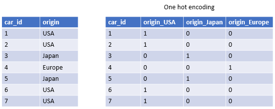

```python
X = pd.get_dummies(X)
X
```

|  | cylinders | displacement | horsepower | weight | acceleration | model_year | origin_europe | origin_japan | origin_usa |
| --- | --- | --- | --- | --- | --- | --- | --- | --- | --- |
| 0 | 8 | 307.0 | 130.0 | 3504 | 12.0 | 70 | 0 | 0 | 1 |
| 1 | 8 | 350.0 | 165.0 | 3693 | 11.5 | 70 | 0 | 0 | 1 |
| 2 | 8 | 318.0 | 150.0 | 3436 | 11.0 | 70 | 0 | 0 | 1 |
| 3 | 8 | 304.0 | 150.0 | 3433 | 12.0 | 70 | 0 | 0 | 1 |
| 4 | 8 | 302.0 | 140.0 | 3449 | 10.5 | 70 | 0 | 0 | 1 |
| ... | ... | ... | ... | ... | ... | ... | ... | ... | ... |
| 393 | 4 | 140.0 | 86.0 | 2790 | 15.6 | 82 | 0 | 0 | 1 |
| 394 | 4 | 97.0 | 52.0 | 2130 | 22.2 | 82 | 1 | 0 | 0 |
| 395 | 4 | 135.0 | 84.0 | 2295 | 11.6 | 82 | 0 | 0 | 1 |
| 396 | 4 | 120.0 | 79.0 | 2625 | 18.6 | 82 | 0 | 0 | 1 |
| 397 | 4 | 119.0 | 82.0 | 2720 | 19.4 | 82 | 0 | 0 | 1 |

398 rows × 9 columns

##### Step3: Train and Test data split

The data must be divided into two parts. First, a training set on which model can be trained. Second, a testing set on which the model can be validated.

**sklearn.model_selection.train_test_split()** method divides the predictors (X) and the corresponding targets (y) into train data (X_train, y_train) and test data (X_test, y_test). It is a general practice to consider 20% of data for testing (test_size=0.2).

```python
# train test split
from sklearn.model_selection import train_test_split
X_train, X_test, y_train, y_test = train_test_split(X, y, test_size = 0.2, random_state = 0)
```

Certain algorithms work well when all the columns are on the same scale. In order to achieve this, data can normalized using various scaler available in Scikit Learn library, such as Standard scaler, MinMax scaler, etc.

When applying any transformation to the data, Scikit Learn applys the transformation in two phases - fit phase and transform phase. During the fit phase, the parameters required for the transformation are learnt. During the transform phase, the data is actually modified or altered.

Generally the fit phase is carried out with train data, and the parameters learnt are applied to transform both the train and the test data.

```python
#Applying standard scaler on the data
from sklearn.preprocessing import StandardScaler
scale = StandardScaler()
scale.fit_transform(X_train)
scale.transform(X_test);
```

##### Step4: Training the model

The Linear Regression model is used to build the model. A linear regression model uses the following equation:

y = B0 + B1*X1 + B2*X2 + + Bn*Xn

y refers to the target and X1,X2…..Xn refer to the predictors. B0 is the intercept and B1,B2…..Bn are the coefficients.

Below code demonstrates the Linear Regression model building using sklearn library on the training data set.

```python
#Importing the algorithm
from sklearn.linear_model import LinearRegression
reg = LinearRegression()
```

```python
#Fitting the model on training data
reg.fit(X_train, y_train)
```

```
LinearRegression()
```

```python
#Checking the coefficient(slope) and intercepts
m = reg.coef_
c = reg.intercept_
m,c
```

```
(array([-0.36669643,  0.02475106, -0.03475517, -0.00627841,  0.11103444,
         0.75647496,  0.72383159,  1.2373965 , -1.9612281 ]),
 -15.513784986400637)
```

##### Step5: Testing the model

The trained linear regression model is used for prediction against the training and testing data set.

```python
#Predicting the target: mpg against the predictors in the training data set
#Predicted data stored in y_pred_train
y_pred_train = reg.predict(X_train)
```

```python
#Predicting the target: mpg against the predictors in the testing data set
#Predicted data stored in y_pred_test
y_pred_test = reg.predict(X_test)
```

##### Step6: Evaluating Model Performance

There are different metrics used to evaluate the performance of the model. Here the R Square score is used.

```python
# Prediction Accuracy in terms of how close is the predicted value of target: mpg
# to the real value in training data set
from sklearn.metrics import r2_score
r2_S = r2_score(y_train, y_pred_train)
r2_S
```

```
0.8215539673604749
```

```python
# Prediction Accuracy in terms of how close the predicted value of target: mpg
# to the real value in testing data set
from sklearn.metrics import r2_score
r2_S = r2_score(y_test, y_pred_test)
r2_S
```

```
0.8294001619272305
```

```python
# new instance of car to be serviced
car={'cylinders':[4], 'displacement':[110], 'horsepower':[70], 'weight':[2500], 'acceleration':[16.5],'model_year':[76], 'origin_europe':[0], 'origin_japan':[1], 'origin_usa':[0]}
print(reg.predict(pd.DataFrame(car)))
```

```
[28.17472294]
```

##### 2.ML Model - Automated classification of incoming cars

##### Step1: Loading Data

```python
# The previously imported DataFrame: cars_df will be used for model building
cars_df
```

|  | mpg | cylinders | displacement | horsepower | weight | acceleration | model_year | origin | name | company | car_type |
| --- | --- | --- | --- | --- | --- | --- | --- | --- | --- | --- | --- |
| 0 | 18.0 | 8 | 307.0 | 130.0 | 3504 | 12.0 | 70 | usa | chevrolet chevelle malibu | chevrolet | Sports |
| 1 | 15.0 | 8 | 350.0 | 165.0 | 3693 | 11.5 | 70 | usa | buick skylark 320 | buick | Sports |
| 2 | 18.0 | 8 | 318.0 | 150.0 | 3436 | 11.0 | 70 | usa | plymouth satellite | plymouth | Sports |
| 3 | 16.0 | 8 | 304.0 | 150.0 | 3433 | 12.0 | 70 | usa | amc rebel sst | amc | Sports |
| 4 | 17.0 | 8 | 302.0 | 140.0 | 3449 | 10.5 | 70 | usa | ford torino | ford | Sports |
| ... | ... | ... | ... | ... | ... | ... | ... | ... | ... | ... | ... |
| 393 | 27.0 | 4 | 140.0 | 86.0 | 2790 | 15.6 | 82 | usa | ford mustang gl | ford | Sedan |
| 394 | 44.0 | 4 | 97.0 | 52.0 | 2130 | 22.2 | 82 | europe | vw pickup | vw | Hatchback |
| 395 | 32.0 | 4 | 135.0 | 84.0 | 2295 | 11.6 | 82 | usa | dodge rampage | dodge | Hatchback |
| 396 | 28.0 | 4 | 120.0 | 79.0 | 2625 | 18.6 | 82 | usa | ford ranger | ford | Sedan |
| 397 | 31.0 | 4 | 119.0 | 82.0 | 2720 | 19.4 | 82 | usa | chevy s-10 | chevy | Hatchback |

398 rows × 11 columns

##### Classification model

Predictors and Target:

- The predictors are the variables that are used to predict the target. All columns excluding name and company are considered as predictors.
- The target variable is 'car_type' which has to be predicted.

```python
#Creating matrix of predictors
X = cars_df.iloc[:, 0:8]
#Setting target
y = cars_df.iloc[:, 10]
print(X)
print(y)
```

```
      mpg  cylinders  displacement  horsepower  weight  acceleration  \
0    18.0          8         307.0       130.0    3504          12.0
1    15.0          8         350.0       165.0    3693          11.5
2    18.0          8         318.0       150.0    3436          11.0
3    16.0          8         304.0       150.0    3433          12.0
4    17.0          8         302.0       140.0    3449          10.5
..    ...        ...           ...         ...     ...           ...
393  27.0          4         140.0        86.0    2790          15.6
394  44.0          4          97.0        52.0    2130          22.2
395  32.0          4         135.0        84.0    2295          11.6
396  28.0          4         120.0        79.0    2625          18.6
397  31.0          4         119.0        82.0    2720          19.4

     model_year  origin
0            70     usa
```

[output cut: 24 more lines]

##### Step2: Preprocessing Data

##### Encoding

The origin feature is a categorical variable, get_dummies function of Pandas is used to encode the origin column:

```python
X = pd.get_dummies(X)
X
```

|  | mpg | cylinders | displacement | horsepower | weight | acceleration | model_year | origin_europe | origin_japan | origin_usa |
| --- | --- | --- | --- | --- | --- | --- | --- | --- | --- | --- |
| 0 | 18.0 | 8 | 307.0 | 130.0 | 3504 | 12.0 | 70 | 0 | 0 | 1 |
| 1 | 15.0 | 8 | 350.0 | 165.0 | 3693 | 11.5 | 70 | 0 | 0 | 1 |
| 2 | 18.0 | 8 | 318.0 | 150.0 | 3436 | 11.0 | 70 | 0 | 0 | 1 |
| 3 | 16.0 | 8 | 304.0 | 150.0 | 3433 | 12.0 | 70 | 0 | 0 | 1 |
| 4 | 17.0 | 8 | 302.0 | 140.0 | 3449 | 10.5 | 70 | 0 | 0 | 1 |
| ... | ... | ... | ... | ... | ... | ... | ... | ... | ... | ... |
| 393 | 27.0 | 4 | 140.0 | 86.0 | 2790 | 15.6 | 82 | 0 | 0 | 1 |
| 394 | 44.0 | 4 | 97.0 | 52.0 | 2130 | 22.2 | 82 | 1 | 0 | 0 |
| 395 | 32.0 | 4 | 135.0 | 84.0 | 2295 | 11.6 | 82 | 0 | 0 | 1 |
| 396 | 28.0 | 4 | 120.0 | 79.0 | 2625 | 18.6 | 82 | 0 | 0 | 1 |
| 397 | 31.0 | 4 | 119.0 | 82.0 | 2720 | 19.4 | 82 | 0 | 0 | 1 |

398 rows × 10 columns

##### Step3: Train and Test data split

The data must be divided into two parts. First, a training set on which model can be trained. Second, a testing set on which the model can be validated.

```python
#train test split
from sklearn.model_selection import train_test_split
X_train, X_test, y_train, y_test = train_test_split(X, y, test_size = 0.2, random_state = 0)
```

```python
#Applying standard scaler on the data
from sklearn.preprocessing import StandardScaler
scale = StandardScaler()
scale.fit_transform(X_train)
scale.transform(X_test);
```

##### Step4: Training the model

The KNeighborsClassifier is used to build the classification model.

Below code demonstrates the classification model building using sklearn library on the training data set.

```python
#Importing the algorithm
from sklearn.neighbors import KNeighborsClassifier
classifier = KNeighborsClassifier(n_neighbors=5,metric="euclidean")
```

```python
#Fitting the model on training data
classifier.fit(X_train, y_train)
```

```
KNeighborsClassifier(metric='euclidean')
```

##### Step5: Testing the model

The trained lclassification model is used for prediction against the training and testing data set.

```python
#Predicting the target: mpg against the predictors in the training data set
#Predicted data stored in y_pred_train
y_pred_train = classifier.predict(X_train)
```

```python
#Predicting the target: mpg against the predictors in the testing data set
#Predicted data stored in y_pred_test
y_pred_test = classifier.predict(X_test)
```

##### Step6: Evaluating Model Performance

There are different metrics used to evaluate the performance of the model. Here the accuracy score is used.

```python
#Training accuracy
from sklearn.metrics import accuracy_score
train_accuracy_score = accuracy_score(y_train, y_pred_train)
train_accuracy_score
```

```
0.8616352201257862
```

```python
#Testing accuracy
from sklearn.metrics import accuracy_score
test_accuracy_score = accuracy_score(y_test, y_pred_test)
test_accuracy_score
```

```
0.8125
```

```python
# new instance of car to be serviced
car={'mpg':[10],'cylinders':[8], 'displacement':[200], 'horsepower':[100], 'weight':[2500], 'acceleration':[16.5],'model_year':[76], 'origin_europe':[0], 'origin_japan':[0], 'origin_usa':[1]}
print(classifier.predict(pd.DataFrame(car)))
```

```
['Sedan']
```